# 智能制造系统设计 · 第 3 讲：工业工程与精益生产

刘训臣

山东科技大学 机械电子工程学院

# 第〇部分 · 课程介绍与本讲定位

- 本讲教学内容与主线：四个内容块＋实验 2 课时（另排）
- 教学进度 · 10 次课全览：本讲是第 3 讲
- 本讲在课程中的位置：从“别做坏”到“别白做”
- **主线**：工作研究 → 程序分析 → 精益生产 → 现场改善与人的关系；实验课用模型算一遍

## 第 2 讲回顾与检查：六个问题

> **2 分钟自测、2 分钟讲评：答不出的那一条，就是今天要补的地基。**

| 问题 | 一句话答案 | 今天怎么用 |
| --- | --- | --- |
| ① 五大工具是哪五个？ | APQP、FMEA、MSA、SPC、PPAP；APQP 策划、FMEA 预防、MSA 保证可信、SPC 监控、PPAP 放行 | 防错措施从 FMEA 来 |
| ② Cpk 1.45 怎么判？ | A 级（1.33～1.67），状态良好、保持现状；1.33 量产线、1.67 关键特性线 | 改善前后用同一口径比能力 |
| ③ 判异八准则记哪几条？ | 口诀：出界、连三、连五、趋势、八缺 C、九同侧、十四交替、十五在 C | 拉动的前提是过程受控 |
| ④ GR&R 三档怎么分？ | < 10% 可接受；10%～30% 有条件接受；> 30% 不可接受 | 现场数据先问可不可信 |
| ⑤ AP 与 RPN 差在哪？ | $\mathrm{RPN}=S\times O\times D$（1～1000）；AP 按 S／O／D 查矩阵得 H／M／L，先看 S | 改善排序先看后果 |
| ⑥ PPAP 交什么、分几级？ | 18 项证据（含 PSW）；提交等级 1～5 由顾客定；核心是 Ppk≥1.67 | 改善成果要有证据闭环 |

- 六问分两类：①⑥ 是证据链，②③④⑤ 是判读；今天把判读对象从“质量”换成“效率”
- 抽查：随机点两人各答一问；答不出不扣分，课后补，下次课前再问
- 接第 2 讲拓展：ISO 9001 与 GJB 9001C 是什么关系？（军工版 9001：多技术状态管理、关键件与定型程序；合同引用即强制）

## 本讲接着讲“标准”：从质量标准到工时标准

> **质量讲“别做坏”，工业工程讲“别白做”，两者都靠“标准”落地：本讲把标准从“产品”推到“动作与时间”。**

| 标准类型 | 回答什么问题 |
| --- | --- |
| 产品标准 | 做到什么：性能、公差、检验判据 |
| 过程标准 | 流程怎么走：谁在何时做什么、留什么证据 |
| 作业标准 | 一个工位怎么做、做多久（标准工时） |

- 前三讲都在讲“标准”，只是对象不同：第 1 讲 ISO 9001／ISO 9000 族管体系，第 2 讲 GJB 9001C 与五大工具管过程证据，本讲管动作与时间。
- 好标准三条判据：**可测量、可比较、可执行**——写清动作、时间、判据，否则只是口号。
- 标准工时就是效率的计量标准；没有标准，“改善”只能靠感觉，改完也无法比较。

## 教学进度 · 10 次课全览

| 次 | 模块 | 主题 |
| --- | --- | --- |
| 1 | 模块 1 与 3.1 | 课程导论、工程与社会与质量工程（一）：国家战略、工程的社会属性、质量管理基础 |
| 2 | 3.1 | 质量工程（二）与质量工具：五大工具 APQP／FMEA／MSA／SPC／PPAP、Cpk、QC 七大手法 |
| **3** | **3.2** | **工业工程与精益生产（＋实验 2 课时：线性规划与工业工程例子）** |
| 4 | 3.3、3.4 | 安全工程与环保工程：海因里希法则、事故树 FTA、风险评估、三废治理、双碳 |
| 5 | 3.5、3.6 | 成本管理与人力资源：成本构成、投资回收期、NPV／IRR、质量成本、人才与激励 |
| 6 | 4.1～4.3 | 企业信息系统（一）：ERP、MES、PLM 与系统集成全景 |
| 7 | 4 | 企业信息系统（二）与 8D：CRM／WMS／APS，8D 八步与软件开发流程 |
| 8 | 工程与社会与工程伦理（一） | 工程事故与伦理准则：凯悦酒店、NSPE 准则、伦理决策框架 |
| 9 | 工程与社会与工程伦理（二） | 风险、安全与责任，工程师与组织：责任判定、组织文化与信任 |
| 10 | 工程与社会与工程伦理（三）与综合 | 技术的社会意义、国际化、AI 伦理；智能设计应用、前沿、课程设计与总复习 |

## 工业工程在智能制造中的位置

> **IE 是智能制造系统的效率底座；数字化放大 IE 的逻辑，不替代它。**

| 关系 | IE 提供什么 | 接口与边界 | 本讲落点 |
| --- | --- | --- | --- |
| 与质量 | 标准作业、防错、减少变异 | 质量工程管“做对”，IE 管“做快、做省” | 防错、作业标准 |
| 与安全 | 人机工程、动作经济、防错 | 动作浪费带来疲劳与伤害；防错让错误做不出、流不走 | 动作分析、防错 |
| 与成本 | 消除浪费、降库存、提效率 | 标准工时是定员、计件、成本估算的共同基准 | 标准工时、八大浪费 |
| 与数字化 | 系统里的 IE 逻辑 | 把标准、节拍、库存、风险变成实时数据与闭环 | MES＋精益 |

- 前三条不是并列：质量与安全是约束，成本是结果；IE 在约束内找效率。
- 顺序不能反：先有标准作业与稳定过程，再上系统；否则只是把浪费记录得更清楚。
- 四个应用点：MES 提升效率、设备与人员动作分析、WMS 优化库存、PLM 的 FMEA。

## 本讲路线图与时间安排

> **主线：方法 → 分析 → 理念 → 现场；实验 2 课时另排，不在本 90 分钟内。**

| 部分 | 入口问题 | 讲什么 | 出口 |
| --- | --- | --- | --- |
| 一 · IE 概念与工作研究 | 效率从哪里来 | 定义与功能；工作研究；标准工时 | 标准工时算得出 |
| 二 · 程序、作业与线平衡 | 流程慢在哪里 | 五种符号、流程程序图；人机图；节拍与平衡率 | 流程图画得出 |
| 三 · 精益生产 | 哪些活动不增值 | 五原则；八大浪费；5S、VSM；拉动、看板、SMED | 浪费数得出 |
| 四 · 现场改善 | 改善怎么固化 | 三现、防错、人机工程、工作设计；伦理 | 方案里有“人的方案” |
| 实验（2 课时，另排） | 怎么用模型算 | LP 三要素、图解法、PuLP、IE 例子 | 模型、代码、解释 |

- 90 分钟＝8 开场/回顾（回顾 4＋衔接 2＋进度与路线图 2；学习目标与伦理落点随讲随带）＋18＋18＋22＋14 讲授＋5 讨论＋5 小结；实验 2 课时另排。
- 例题页为课后精读：课上择讲 1～2 道，其余按“题干页＋分步解答”课后精读。
- 课前准备：计算器、A4 纸与直尺；Python 3.10＋PuLP 跑通；预习 3.2 节。

## 学习目标：四条能力与验收标准

> **承上**：第 2 讲解决“别做坏”，本讲解决“别白做”。**四条能力对应四个可检查的动作：画流程、算工时、画鱼骨、算平衡。**

| 能力 | 具体要求 | 验收标准（可检查） | 落在哪里 |
| --- | --- | --- | --- |
| 能分析流程 | 用五种符号画流程程序图，统计操作、检验、搬运、等待、暂存 | 给一条 10 步流程，5 分钟内画出并算出等待与搬运占比 | 第一、二部分 |
| 能算工时 | 正常时间＝观测×评比；标准时间＝正常×（1＋宽放） | 观测 6.00 min、评比 1.05、宽放 12% → 7.056 min，8.50 件/h | 第一部分 |
| 能画鱼骨图 | 人机料法环五支主干，每支 2～3 条原因，圈出主因 | 3 分钟画完五支，主因有数据或 5Why 依据，措施对得上 | 第二、五部分 |
| 能算线平衡 | 节拍、理论最少工位、平衡率、平滑指数 | 5 工位 60／72／68／75／65 s → 平衡率 90.7%，瓶颈 75 s 大于节拍 72 s | 第二、七部分 |

- 四条里两条靠画、两条靠算；验收一律用可检查的动作，不写“理解”“掌握”
- 考试直接考鱼骨图、ECRS／ESCRI 与八大浪费；工时与线平衡落在作业、实验与课程设计
- 另有一条不写进表：每个效率数字都要能说出“对谁有利、代价由谁承担”

## 本讲伦理与社会落点：效率与人的关系

- 效率提升从来不是纯技术问题：**同样的产出，用人更少；少掉的人去哪里？**
- 改善的两个方向可能相反：**降低劳动强度**（动作经济、工装改进）与**提高劳动强度**（加定额、减节拍）
- 现场改善的权力不对称：定标准的人不执行标准，执行标准的人不参与定标准
- 本讲两个讨论点：自动化对岗位的影响；劳动强度与工作设计

> 一句话：**效率是手段，人不是手段。**

## 推导留给 AI：课程介绍与本讲定位

- 用一句话说清工业工程与质量工程的分工，再让 AI 举例说明两者在一条产线上的分工。
- 精益生产与工业工程是什么关系？让 AI 给出三种不同的表述并判断哪种更准确。
- “效率提升”与“劳动强度提高”在数据上如何区分？让 AI 设计两个可观测指标。
- 查证：泰勒制（科学管理）与精益生产在“人”的假设上有什么不同？

## 产教融合 · 本讲企业真题：八工位装配线的两个平衡率口径

> **企业场景：**企业齿轮装配线 8 个工位工时 50/40/45/35/30/55/25/20 s，需求节拍 60 s，瓶颈在接线 55 s。

| 企业真实问题 | 本讲工具 | 学生产出 |
| --- | --- | --- |
| 平衡率低、工位间忙闲不均，产出够但分配不匀 | 程序分析、ECRS、线平衡与平滑指数 | 线平衡改善方案（目标按需求节拍≥85%） |

- **两个口径：**按需求节拍 $E=300/(8\times60)=62.5\%$；按瓶颈 $E=300/(8\times55)=68.2\%$。
- **教案对应：**第三章 3.2 工业工程；**企业参与：**工业工程部提供测时视频与工位布置图
- **验收：**两个平衡率口径写清分母；ECRS 方案可执行，并重算平衡率、平滑指数与产出。

# 第一部分 · 工业工程的概念、目标与工作研究

- 工业工程的定义、目标与六个特征
- 四项基本功能：规划、设计、评价、创新
- 工作研究：方法研究＋作业测定（秒表、抽样、PTS）
- 标准工时：评比、宽放、算例与维护
- **承上**：上一部分回答了“本讲为什么从质量标准走到工时标准”；本部分要回答 IE 是什么、工作怎么研究、标准工时怎么算出来。

## IE 的定义与四个目标

> **承上**：第〇部分说明了本讲为什么从质量标准走到工时标准；这一页回答 IE 到底是什么、它要同时追哪几个目标。
- **定义**（AIIE，1955）：IE 对人员、物料、设备、能源与信息组成的集成系统做设计、改善和设置，并综合运用数学、物理与社会科学知识，对系统成果作确定、预测和评价。
- **效率**：以更少投入获得同样产出，或以同样投入获得更多产出；IE 看的是系统产出率，而不只是单机速度。
- **质量**：一次做对、过程稳定；质量靠过程保证，不靠最后检验把不合格品筛出去。
- **成本**：看总成本与全生命周期成本，而不只看采购单价或人工单价。
- **安全**：把风险、人机工效与劳动强度一并纳入方案；效率不能以伤害为代价。
- **六个特征抓两条**：整体系统与以人为本；只压节拍会伤质量与安全、只降成本会伤可靠性与士气，IE 要用数据做多目标权衡。

**结论：IE 把“多、快、好、省、安全”变成可测量、可比较、可实施的系统方案；四个目标互相约束，缺一个的方案都不算好方案。**

## IE 的基本功能：规划、设计、评价、创新

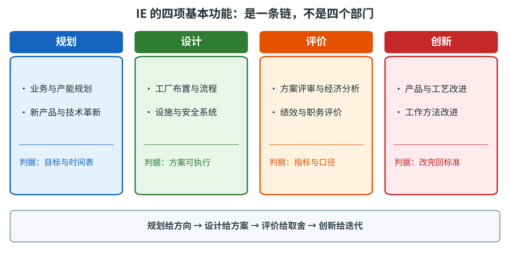

- **是什么**：规划（做不做）、设计（怎么做）、评价（值不值）、创新（下次怎么更好）——四项功能是一条链，不是四个部门
- **怎么判断**：规划看目标、资源与时间表；设计看能否落成方案；评价看指标与口径；创新看是否回到标准
- **一句话**：缺评价，创新就是拍脑袋；缺设计，规划就停在纸上
- **输出**：目标与资源、可执行方案、评价口径、新标准

## IE 的方法体系与知识领域

| 方法类别 | 典型工具 |
| --- | --- |
| 工效学方法 | 人机界面设计、工作空间与环境设计、疲劳与安全 |
| 工作测量方法 | 时间研究、工作抽样、预定时间标准 |
| 决策应用方法 | 方案取舍分析、价值工程、学习曲线、激励机制 |
| 量化方法 | ABC 分类、流程程序分析、生产线平衡、甘特图 |

- IE 知识领域有 17 个分支，包括生物力学、工程经济、组织规划与理论等
- 基础 IE 的主干只有一句：**用方法研究简化工作，用作业测定定标准时间**

## IE 发展史：从泰勒到丰田

| 阶段 | 代表 | 关键贡献 | 对 IE 的意义 |
| --- | --- | --- | --- |
| 20 世纪初 | 泰勒 | 时间研究、标准化（1911） | 经验管理走向科学管理 |
| 1910 年代 | 吉尔布雷斯夫妇 | 动作研究、动素、动作经济 | 方法研究有了微观工具 |
| 1913 年 | 福特 | 移动装配线、零件互换性 | 大量生产与节拍化 |
| 二战后 | 丰田（大野耐一） | 准时化、自働化、看板、改善 | 多品种小批量的系统方法 |
| 20 世纪中后期 | 运筹学、系统工程 | 线性规划、排队论、仿真 | IE 从车间走向系统 |

- 一条主线：从“管单个工人的动作”走向“设计整个系统”，从大量生产走向多品种小批量。
- 四条线：泰勒给“时间”、吉尔布雷斯给“动作”、福特给“节拍”、丰田给“拉动”；遗产是标准方法、标准时间、标准作业。
- 历史评价分开看：泰勒制有时代局限，也被简化为“压榨工人”，其原意含管理与工人分担责任。
- 一条边界：IE 能优化给定系统，不能替代产品创新；技术路线错了，效率越高越危险。

## 泰勒与吉尔布雷斯：科学管理与动作研究

**两种研究方式：泰勒管“时间”，吉尔布雷斯管“动作”，两条线合起来才是工作研究。**

- **泰勒四原则**（1911《科学管理原理》）：建立科学（标准方法、标准工具、标准时间）→ 科学选训 → 真诚合作 → 责任分担。
- **吉尔布雷斯与动素**：把动作分解为 18 种基本单元，分三类——有效动素保留并简化、辅助动素压缩合并、无效动素优先消除。
- **研究手段**：砌砖现场做动作分解，用可调脚手架、砖块定置与标准动作减掉弯腰、转身、取砖等无效动作。
- **动作经济四原则**：减少动作数量、双手同时动作、缩短动作距离、使动作轻快自然有节奏。
- **莉莲·吉尔布雷斯**：把心理学与疲劳研究带入动作研究；今天的动作捕捉、数字人体、工效仿真是它的延续。
- **两条线都不是“让人更快”**：先删掉不必要的动作与等待，再谈标准化；泰勒制被简化为“压榨”是误读，其原意含管理与工人分担责任。

## IE 在中国：从引进入厂到智能制造

> **IE 在中国不是“引进一套方法”，而是把方法接到自己的现场与数据上。**

| 阶段 | 时间 | 标志性做法 | 今天还在用的东西 |
| --- | --- | --- | --- |
| ① 引进 | 1980 年代 | 高校与工厂系统引进 IE | 工作研究、标准工时与宽放 |
| ② 建专业 | 1990 年代 | 高校设 IE 专业，企业试点 | 程序分析、作业测定、标准作业 |
| ③ 合流 | 2000 年代 | 与精益、六西格玛合流 | 5S、VSM、看板与改善提案 |
| ④ 数字化 | 2010 年代以后 | 与数字化结合 | 节拍、平衡率进系统，数据闭环 |

- 四阶段一条线：先学方法、再建专业、再成体系、最后上系统；每一步都给现场加一条可算的依据
- 三个现实约束：人多，定员与多能工是头等事；以制造为主，改善对象多在装配与机加工；改善对象在现场，标准要能在工位执行
- 与智能制造的分工：IE 给逻辑与判据（节拍、工时、平衡率），数字化给实时数据与闭环（采集、追溯、预警）
- 判据：IE 的产出仍是“可执行的标准＋可算的账”——标准能培训、账能复核

## 工作研究：方法研究＋作业测定

> **承上**：上一页把 IE 的目标落在“多目标权衡”上；这一页回答用什么方法把目标落到可执行的“方法＋时间”上。

**工作研究＝方法研究（怎么干更省）＋作业测定（干一次多久），两支路合成工作标准。**

| 维度 | 方法研究 | 作业测定 |
| --- | --- | --- |
| 回答的问题 | 应该怎么做？ | 按标准方法做需要多久？ |
| 核心任务 | 简化程序、操作与动作，形成标准方法 | 观测、评比、宽放，形成标准时间 |
| 主要工具 | 程序分析、操作分析、动作分析、ECRS | 秒表测时、工作抽样、预定时间标准 |
| 输出 | 标准作业方法、作业指导书 | 标准时间、产能与定员依据 |
| 成功判据 | 更省、更稳、更安全 | 可重复、可比较、可复核 |

- **顺序不能倒**：先定方法再测时间；先测时再补方法，等于把错误方法固化。
- **合成物**：两支路合成工作标准（标准作业方法＋标准时间＋质量与安全要求），再进入培训、排产、定员与绩效。
- **判据**：方法研究看“该不该、顺不顺”，作业测定看“稳不稳、公不公平”。

**结论：先定方法、再测时间，两条腿合起来才是工作标准；顺序反了，测出来的只是旧方法的速度。**

## 方法研究：程序、操作与动作

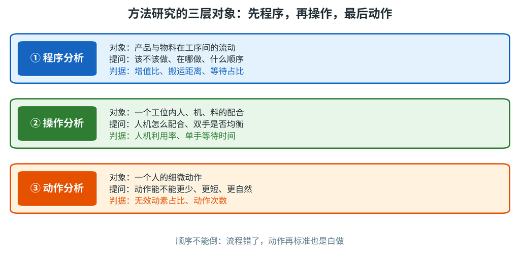

- **判据**：改哪一层，看问题是“做不做”（程序）、“怎么配合”（操作）还是“手怎么动”（动作）
- **三层对象**：程序看工序间流动，操作看工位内配合，动作看细微动作；上一层不改，下层优化会被浪费
- **输出**：程序图、人机程序图、双手操作图、动素分析，三层各有一套图

## 方法研究的图表体系：五类分析与选图判据

> **判据：先定要回答的问题，再选图；图是记录工具，不是成果。**

| 分析类别 | 回答的问题 | 常用图 | 统计输出 |
| --- | --- | --- | --- |
| 工艺程序分析 | 产品经过哪些工序、顺序对不对 | 工艺程序图 | 工序数与顺序 |
| 流程程序分析 | 物料或人怎么流动、哪里等与搬 | 流程程序图（人型／物型） | 五类活动次数、时间、距离 |
| 布置与路径分析 | 距离能不能更短、路线有没有回头 | 线图、线路图、从至表 | 搬运距离与路线 |
| 闲余能量分析 | 人与机的空闲分别在哪里 | 人机程序图 | 人机利用率 |
| 双手作业分析 | 两只手是否均衡、有没有单手空闲 | 双手操作图 | 动作分解与负荷 |

- 选图三步：先定对象（流程／工位／动作）→ 再定要回答的问题 → 最后选图，不要一上来就画
- 读图要点：先数符号看流程长短，再看时间与距离，最后找瓶颈与回头路线——统计不出等待与搬运的图，只是示意图

## 作业测定：三种常用方法

> **承上**：上一页把工作研究分成“方法”与“时间”两条腿；这一页回答时间这条腿有哪几种量法、各自适用什么场景。
- **秒表测时法**：对重复性作业做现场观测、记录与计算，适合周期短、批量大的工序。
- **工作抽样法**：在随机时点做瞬时观测，用样本比例推断设备或人员的活动时间分布；样本量 $n=\dfrac{Z^2p(1-p)}{e^2}$（$n$ 为观测次数/次，$Z$ 为置信水平系数/无量纲，95% 时取 1.96，$p$ 为活动发生比例/无量纲，$e$ 为允许误差/无量纲；取 $p=0.3$、$e=0.05$ 时 $n\approx323$）。
- **预定时间标准（PTS）**：用已发布的动作时间表合成作业时间，不必到现场测时。
- **评比与宽放**：观测时间先乘评比系数 $R$（无量纲）修正为正常时间，再乘 $(1+A)$ 得标准时间，$A$ 为总宽放率（无量纲，按 % 计）。

**结论：三种方法按“作业是否重复、有无现场”分工：稳定重复用秒表，非重复用抽样，新产品用 PTS；测出的时间都要经评比与宽放才算标准。**

## 秒表测时法的步骤

- ① 明确目的与对象：测哪道工序、用什么方法、给谁用
- ② 划分作业单元：起止点可辨认，人工与机器分开，异常单独记
- ③ 确定观测次数：$n=(Zs/(e\bar{x}))^2$，例 $\bar{x}=30$ s、$s=3$ s、$e=5\%$、$Z=1.96$，得 $n\approx16$
- ④ 准备器具：秒表或平板、记录表、笔，事先与操作者沟通
- ⑤ 现场观测并记录异常：连续法、归零法或周程法，待料、换刀、故障单独标注
- ⑥ 整理数据：剔除异常值，计算平均观测时间
- ⑦ 评比：把观测速度折算到正常速度，得正常时间
- ⑧ 宽放：加私事、疲劳、作业、管理、特殊宽放，得标准时间
- ⑨ 复核：换人、换班复测，确认标准时间可重复
- 常见错误：先测时后分单元、把异常当正常、只测快的人

## 工作抽样：原理、算例与实施

| 项目 | 公式或数据 | 结果 |
| --- | --- | --- |
| 样本量 | $n=\frac{Z^2p(1-p)}{e^2}$，取 $Z=1.96$、$p=0.25$、$e=0.03$ | $n=800.33$，取 801 |
| 观测比例 | 2400 次观测中 540 次等待 | $\hat p=0.225$ |
| 95% 置信区间 | $\hat p\pm1.96\sqrt{\hat p(1-\hat p)/n}$ | $[0.2083,0.2417]$ |
| 每班等待时间 | $0.225\times480$ min | 108 min，区间 $[100.0,116.0]$ min |

- 原理：随机时点做瞬时观测，用“出现次数比例”估计“时间比例”；$p$ 未知时取 0.5 最保守。
- 实施五步：定义互斥穷尽的状态 → 随机数生成时点（不挑整点）→ 试观测估 $p$ → 正式观测记录瞬间状态 → 整理并校验精度，误差超限补测。
- 分层：按班次、区域、人员分层，否则样本偏向某一班；固定整点与“事后回忆”都会引入偏差。
- 适用边界：短周期重复作业用秒表或 PTS，工作抽样适合管理、维修等非重复活动。

## 预定时间标准：MOD、MTM 与查表算例

- PTS 用动作时间表合成正常时间，可投产前预估；宽放不能忘。
- MOD：21 种动作，$1\ \mathrm{MOD}=0.129\ \mathrm{s}$（$1\ \mathrm{min}\approx465\ \mathrm{MOD}$）；MTM-1 更细更准（$1\ \mathrm{TMU}=0.036\ \mathrm{s}$），培训成本高。

| 动作 | MOD 码 | MOD 值 | 时间/s |
| --- | --- | --- | --- |
| 伸手取螺钉 | M3G1 | 4 | 0.52 |
| 螺钉放入孔 | P2 | 2 | 0.26 |
| 伸手取垫片 | M2G1 | 3 | 0.39 |
| 放垫片 | P1 | 1 | 0.13 |
| 伸手取扳手 | M3G1 | 4 | 0.52 |
| 扳手放到位 | P2 | 2 | 0.26 |
| 合计 | — | 16 | 2.06 |

- 正常时间 $=16\times0.129=2.06$ s；宽放 15% → 标准 $2.37$ s；整件重复 6 次 → $14.2$ s、约 253 件/h。
- 局限：动作表未含产品、布局与疲劳，须试产校准；码值与宽放口径要留记录。

## 标准工时的构成

> **承上**：上一页介绍了三种测时方法；这一页回答测得的观测时间怎样一步步变成可用于排产与定员的标准时间。

**标准时间：合格工人按标准方法、正常速度完成单位作业所需的时间，含宽放。**

| 组成 | 符号/单位 | 作用 | 确定方法 |
| --- | --- | --- | --- |
| 观测时间 | $T_o$（min） | 现场实测的平均时间 | 秒表测时或工作抽样 |
| 评比系数 | $R$（无量纲） | 把观测速度折算到正常速度 | 速度评比、平准化法 |
| 正常时间 | $T_n$（min） | 正常速度下的净作业时间 | $T_n=T_o\times R$ |
| 宽放率 | $A$（%） | 补偿私事、疲劳与管理中断 | 五类宽放相加 |
| 标准时间 | $T_s$（min） | 排产、定员、报价的基准 | $T_s=T_n\times(1+A)$ |

**结论：标准时间＝观测×评比×宽放，乘的次序不能乱；宽放只加在正常时间上，方法一变标准就要重定。**

## 宽放时间的五个类别

| 类别 | 包含 | 主要责任 | 核定依据 |
| --- | --- | --- | --- |
| 私事宽放 | 饮水、如厕、短暂休息 | 员工与班组长 | 固定比例或协议 |
| 疲劳宽放 | 负荷、姿势、环境疲劳 | 工艺与工效 | 负荷评估、疲劳研究 |
| 作业宽放 | 换刀、清理、微调、润滑 | 工艺与设备 | 作业标准、现场实测 |
| 管理宽放 | 交接班、班前会、待料 | 管理层 | 管理流程、停线记录 |
| 特殊宽放 | 高温、粉尘、噪声、夜班 | 安全与人事 | 法规、职业卫生标准 |

- 五类相加得总宽放率，不是每类乘一遍；每类都要有观测、记录与依据才可复核。
- 私事宽放不能取消；疲劳宽放随强度与环境分档；管理宽放是管理改善对象，不是工人偷懒。
- 特殊宽放要有法规或职业卫生依据，并与疲劳宽放避免重复计同一因素。
- 宽放率不是越低越好：压宽放会把标准时间变成“不可持续的时间”；方法变了要重算。

## 评比方法：四种方法与平准化四因素

- 评比：把观测对象的作业速度折算到“正常速度”的系数，记为 $R$
- 速度评比以标准速度 100%，快则大于 100%，慢则小于 100%
- 平准化：熟练、努力、条件、一致性四因素分别打分再相加；客观评比按难度修正；合成评比用于高精度
- 本例：$R=1+0.11+0.05+0.00-0.02=1.14$；正常时间 $=6.00\times1.14=6.84$ min

| 因素 | 本例等级 | 系数/增量 | 判读 |
| --- | --- | --- | --- |
| 熟练 | B1 | +0.11 | 略高于标准 |
| 努力 | C1 | +0.05 | 中等偏上 |
| 条件 | D | 0.00 | 一般 |
| 一致性 | E | -0.02 | 略有波动 |
| 合计 | — | 1.14（含基数 1） | 评比系数 |

## 例题：标准工时计算 —— 题干与思路

**背景**：练“观测→正常→标准→产量”的换算与宽放基数，看好评比方向。

| 作业单元 | 观测时间/min | 评比系数/无量纲 | 正常时间/min（待求） |
| --- | --- | --- | --- |
| 取件装夹 | 1.20 | 1.05 | — |
| 启动加工 | 0.30 | 1.00 | — |
| 卸件放置 | 0.90 | 1.10 | — |
| 尺寸检验 | 0.40 | 0.95 | — |

- **求**：① 正常时间 $T_n$（min，2 位小数）；② 总宽放率 $A$（%，整数；五类宽放为私事 5%、疲劳 6%、作业 3%、管理 2%、特殊 2%）；③ 标准时间 $T_s$（min，2 位小数）；④ 标准产量 $Q$（件/h，1 位小数）。
- **公式**：$T_n=\sum_{i=1}^{4}T_{oi}R_i$（$T_{oi}$ 为第 $i$ 单元观测时间/min，$R_i$ 评比系数/无量纲）；$T_s=T_n(1+A)$（$A$ 为总宽放率，小数）；$Q=60/T_s$（件/h）。
- **路线**：① 单元观测时间乘评比系数 → ② 四个单元相加得 $T_n$ → ③ 五类宽放率相加得 $A$、求 $T_s$ → ④ 用 $T_s$ 求时产 $Q$。

## 例题：观测均值与宽放（十周期） —— 题干与思路

**背景**：练异常值剔除与“观测均值→标准时间”的口径。

| 周期 | 观测时间/min | 周期 | 观测时间/min |
| --- | --- | --- | --- |
| ①～⑤ | 5.2、5.0、5.4、5.1、5.3 | ⑥～⑩ | 12.0、5.2、5.1、5.0、5.3 |

- **已知**：评比系数 $R=1.10$（速度评比）；总宽放率 $A=20\%$＝私事 5＋疲劳 8＋作业 4＋管理 2＋特殊 1；第 ⑥ 周期 12.0 min 为换刀异常（有记录）。
- **求**：① 剔除异常后的观测均值 $\bar T_o$（min，3 位小数）；② 正常时间 $T_n$（min，3 位小数）；③ 标准时间 $T_s$（min，3 位小数）；④ 标准产量 $Q$（件/h，2 位小数）。
- **公式**：$\bar T_o=\frac{1}{n}\sum_{i=1}^{n}T_{oi}$（$T_{oi}$ 为第 $i$ 个有效周期的观测值/min，$n$ 为有效周期数/个）；$T_n=\bar T_o R$；$T_s=T_n(1+A)$；$Q=60/T_s$（件/h）。
- **路线**：① 判定并剔除异常、写明理由 → ② 剩余周期求和后除以 $n$ 得均值 → ③ 乘 $R$ 得 $T_n$、再乘 $(1+A)$ 得 $T_s$ → ④ 60 除以 $T_s$ 得时产。

## 例题：观测均值与宽放（十周期） —— 分步解答

- **第 1 步 判异常、定有效周期**：12.0 min 明显偏离其余 9 个（5.0～5.4 min）且为换刀异常，剔除并记录理由；$n=9$。
- **第 2 步 求观测均值（Σ 与 n 是中间量）**：Σ $=5.2+5.0+5.4+5.1+5.3+5.2+5.1+5.0+5.3=46.6$ min，$\bar T_o=46.6/9=5.1778\approx5.178$ min。
- **第 3 步 求正常时间与标准时间**：$T_n=5.1778\times1.10=5.6956\approx5.696$ min；$A=5\%+8\%+4\%+2\%+1\%=20\%$，$T_s=5.6956\times1.20=6.8347\approx6.835$ min。
- **第 4 步 求标准产量**：$Q=60/6.8347=8.779\approx8.78$ 件/h。
- **判读**：本工序标准时间约 6.835 min/件、时产约 8.78 件；宽放口径要写清：若只算私事与疲劳 13%，$T_s=6.436$ min，比 20% 口径低 5.8%。
- **易错点/验算**：① 不剔除异常时均值 5.860 min、$T_s=7.735$ min，会把标准时间高估 13.2%；② 评比乘在均值上、宽放乘在正常时间上，两步不能合并成一次乘；③ 验算 $5.6956\times1.20=6.8347$ ✓。

## 学习曲线：用法与边界

公式

$$T_n=T_1\,n^{\log_2 r}$$

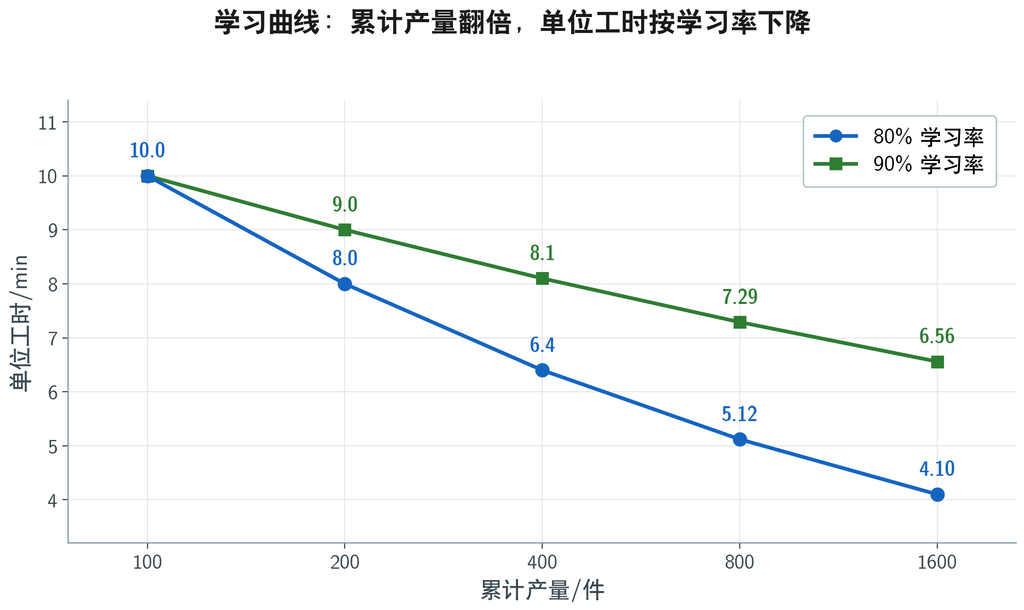

- 读图：以 100 件为基数，1600 件时 80% 线为 4.10 min、90% 线为 6.56 min，差距越拉越大。
- 用法：新品报价、爬坡产能估算、标准工时修订；标准工时按稳态定、报价按累计产量分段，两笔账分开算。
- 边界与风险：手工装配明显、高度自动化不明显；连续三批学习率不一致就查工艺；拿它压价，是让工人为学习过程买单。

## 标准工时的维护：修订、争议与员工参与

**标准工时是快照，不是铁板：方法、设备、改善一变，标准就得跟着改。**

| 触发情形 | 动作 | 判据与记录 |
| --- | --- | --- |
| 方法改变 | 重测并重定标准方法 | 新方法有作业指导书与测时记录 |
| 设备更新 | 复测单元时间，重算自动与手动比例 | 设备参数与时间同步更新 |
| 改善落地 | 改善验收后立即改标准 | 验收记录与新版发布日期 |
| 评比争议 | 复评、留证据、双方确认 | 评比依据可追溯 |
| 岗位轮换 | 复核人员能力，补培训 | 培训与认证记录 |

- 修订五步：重测 → 评审 → 发布 → 培训 → 旧版回收；少一步就是两版并存
- 三类争议：评比依据（凭什么系数）、宽放口径（算哪几类）、计件单价联动（标准一变钱就变）
- 员工参与：测时在场、结果公示、申诉通道；参与不是客气，是让标准可执行
- 判据：多数人长期可维持；旧版不并存；争议有记录、有答复
- 常见失败：只发新版不收旧版、只改数字不改作业指导书、争议拖着不答复
- 一句话：标准的时间是算出来的，标准的权威是谈出来的

## IE 小结：方法到标准的闭环

| 环节 | 核心问题 | 输出 |
| --- | --- | --- |
| 方法研究 | 应该怎么做？ | 标准方法、作业指导书 |
| 作业测定 | 需要多长时间？ | 正常时间、标准时间 |
| 标准作业 | 方法、时间、质量与安全如何合在一起？ | 可执行、可培训的标准 |
| 培训执行 | 人人会做、按标准做吗？ | 培训、认证、现场审核 |
| 评价修订 | 标准还适用吗？ | 改善、修订、再标准化 |

- 两个闭环：方法（程序→操作→动作→ECRS→新方法）、时间（测时→评比→宽放→标准时间→排产定员）。
- 标准是基线不是终点：没有标准，改善无法比较；标准不修订，改善无法积累。
- 三个接口：质量（标准作业＋防错）、计划（节拍与产能）、人（培训、绩效、劳动强度）。
- 常见失败：只定标准不培训；只考核不改善；标准由办公室定，现场不参与。

## 推导留给 AI：工业工程概念与工作研究

- 泰勒的时间研究与吉尔布雷斯的动作研究，分别对应本讲的哪两个层次？
- 工作抽样要估计某工位“等待”占比，p 未知时如何取样本量？让 AI 给出保守方案。
- 标准工时为什么要有评比系数与宽放率？去掉它们会发生什么？
- 查证：AIIE 的 IE 定义在近 20 年有没有修订？修订反映了什么变化？

# 第二部分 · 程序分析、作业分析与生产线平衡

- 程序分析的五种符号与流程程序图
- 操作与动作分析：人机图、双手图、SIMO、动素
- 节拍、瓶颈、生产线平衡与山积表
- ECRS／ESCRI、5W1H 提问法与改善案例
- **承上**：上一部分把单个工序算成了标准工时；本部分要回答整条流程与整条线怎么画、怎么算、怎么分匀。

## 程序分析的目的、产出与三个“点”

> **判据：程序分析的产出是“能算账的图”，不是“好看的图”。**
- **是什么**：以整条流程为对象，查明各环节的先后、时间、距离与等待，把流程变成可统计对象。
- **为什么先做**：流程错了，工位与动作再优化也是白做；程序改善的收益通常最大。
- **五个目的各有指标**：缩短流程（步骤数）、减少搬运（距离）、消除等待（等待占比）、降低在制（WIP）、明确控制点（控制点清单）。
- **三个“点”**：控制点（影响质量或安全的关键工序）、服务点（备料、检验、返修、配送）、瓶颈点（决定产能上限的工序）。
- **改善顺序**：先找瓶颈（决定产出）→ 再消除等待与搬运（不增值）→ 最后优化操作与动作。
- **输出四件套**：现状图、统计表、改善方案、效果对比。

## 程序分析：五种符号与记录统计口径

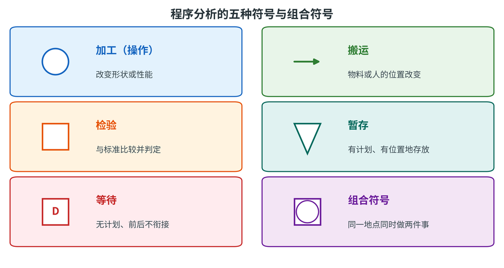

- **五种符号**：○加工、→搬运、□检验、▽暂存、D等待；一工序一行，按时间顺序向下排。
- **成对判据**：加工改形状／性能，检验与标准比；暂存有计划、有记录、有位置，等待无计划、无期限、前后不衔接。
- **记录口径**：先定流程边界，再按类别单独编号，符号旁标时间、距离、数量；最后统计五类活动的次数、总时间、总距离与增值比。

## 工艺程序图与流程程序图的区别

| 维度 | 工艺程序图 | 流程程序图 |
| --- | --- | --- |
| 分析对象 | 产品全部工艺过程与零部件关系 | 单一物料或人员的全部活动 |
| 记录符号 | 只记操作○与检验□ | 五种符号全记 |
| 物流信息 | 不记搬运、等待与距离 | 记时间、距离、等待与暂存 |
| 结构 | 树状，反映零部件从属与装配关系 | 线状，按时间顺序排列 |
| 主要用途 | 看产品怎么做出来、哪些件先做 | 看物流哪里绕、哪里等、哪里搬 |
| 典型问题 | 工艺是否必要、顺序是否合理 | 哪段搬运最多、等待最长 |

- 一句话：工艺程序图看“产品结构”，流程程序图看“活动轨迹”
- 工艺程序图是“树”，流程程序图是“线”
- 工艺程序图也能发现多余工序与重复检验
- 先用工艺图定“做哪些工序”，再用流程图定“怎么流动”
- 两张图都按工艺顺序编号，统计操作与检验次数，便于前后对比
- 常见错误：流程图画成工艺图，漏掉搬运与等待，改善就只剩“简化”
- 同一流程按对象画**人型**（人怎么走）或**物型**（料怎么流）：符号与统计口径随之变化

## 例题：流程程序图统计（阀体件） —— 题干与思路

**背景**：练“流程程序图→五类统计→增值比”的统计口径。

| 活动（符号、时间/s、距离/m） | 活动（符号、时间/s、距离/m） |
| --- | --- |
| ① ▽ 毛坯入库：0 | ② → 毛坯到锯床：90，12 |
| ③ ○ 锯切下料：60 | ④ → 到数控车：45，6 |
| ⑤ ○ 车削：180 | ⑥ □ 尺寸检验：40 |
| ⑦ D 等待热处理：300 | ⑧ ○ 热处理：600 |
| ⑨ → 到成品库：60，9 | ⑩ ▽ 成品入库：0 |

- **求**：① 五类活动的次数、时间合计与搬运距离（次、s、m，整数）；② 总时间 $\sum t$（s，整数）与增值比（%，1 位小数）；③ 搬运＋等待的合计时间及占比（s、%，1 位小数）。
- **公式**：增值比 $=T_{\mathrm{VA}}/\sum t$（$T_{\mathrm{VA}}$ 为增值时间，只算 ○ 加工的合计/s；$\sum t$ 为五类活动合计/s）；占比 $=$ 该类时间$/\sum t$。
- **路线**：① 按五种符号逐项归类计数 → ② 分类汇总时间与距离 → ③ 求 $\sum t$、增值比与占比 → ④ 换轴类件同口径再算一次。

## 例题：流程程序图统计（阀体件） —— 分步解答

- **第 1 步 按符号归类计数**：○ 加工 3 次（锯、车、热处理）；→ 搬运 3 次；□ 检验 1 次；▽ 储存 2 次；D 等待 1 次。
- **第 2 步 分类汇总时间与距离**：加工 $60+180+600=840$ s；搬运 $90+45+60=195$ s、距离 $12+6+9=27$ m；检验 40 s；储存 $0+0=0$ s；等待 300 s。
- **第 3 步 求总时间**：$\sum t=840+195+40+0+300=1375$ s（储存时间虽为 0，次数仍要计入，否则类别不全）。
- **第 4 步 求增值比与占比**：增值比 $=840/1375=61.09\%\approx61.1\%$；搬运＋等待 $=195+300=495$ s，占 $495/1375=36.0\%$（其中等待 $300/1375=21.8\%$、搬运 $14.2\%$）；轴类件 $161/330=48.79\%\approx48.8\%$。
- **判读**：阀体件增值比 61.1%、非增值 36.0%，等待 300 s（21.8%）是最大单项——先改热处理批量与排程；轴类件（161/330＝48.8%）更低，先压等待与暂存、再合并搬运。
- **易错点/验算**：① 增值比只算 ○ 加工；② 回算 $840+195+40+0+300=1375$ ✓；③ 储存 0 s 不等于无损失（占资金、场地与二次搬运）。

## 流程程序图改进：ECRS 与改善案例

| 措施 | 对象 | 变化 | 效果 |
| --- | --- | --- | --- |
| E 取消 | 毛坯入库暂存 | 供应商直送下料区 | 省 30 min，少一次入库 |
| E 取消 | 车床后等待 | 看板排产，按节拍投放 | 省 25 min |
| C 合并 | 铣削与钻孔 | 加工中心一次装夹 | 14→11 min，少一次搬运 |
| R 重排 | 设备位置 | 按工艺顺序成组布置 | 搬运 155→95 m、48→34 min |
| S 简化 | 车削与检验 | 专用夹具、专用检具 | 12→10 min、6→4 min |

- 活动项 16→13 项；周期 330→254 min（降 23.0%）；搬运距离降 38.7%；增值比 48.8%→61.4%。
- 改善顺序体现 ECRS：先取消两次，再合并、重排，最后才简化；热处理 120 min 未动，仍是最大单项。
- 装配工序小案例：12 步→8 步、单件 300→240 s（效率 +25%），搬运 3 次 45 m→1 次 12 m；效率提升不等于可裁同样比例的人。

## 布置与路径分析：从至表

- 布置分析看“设备放哪”，路径分析看“物料怎么走”：线图 → 线路图 → 从至表算账。
- 从至表：行是起点、列是终点，格内填搬运次数、重量或距离；对角线以上为顺流、以下为倒流，倒流越多物流越乱。
- 物流量 $L=\sum_i\sum_j f_{ij}d_{ij}$（$f$ 次数、$d$ 距离），距离口径要统一。

| 流量对 | 次数/批 | 现距离/m | 新距离/m |
| --- | --- | --- | --- |
| A→B | 60 | 20 | 10 |
| B→C | 45 | 10 | 10 |
| C→D | 40 | 20 | 10 |
| B→D | 25 | 10 | 20 |
| A→C | 20 | 10 | 20 |

- 现状 A-C-B-D-E-F 为 2900 次·m，改 A-B-C-D-E-F 后 2350 次·m，降 19.0%；大流量对 A→B 由 20 m 缩到 10 m，单对省 600。
- 局部变差（A→C、B→D）是正常的，评价看总量；约束是通道、承重、动力与安全距离，先线图核对真实距离再乘搬运成本做经济比较。

## 人机料法环在 IE 中的用法

**4M1E 不只是画鱼骨图，它是每一道工序的记录框架。**

| 要素 | 在流程中记录什么 | 常见损失 | 改善问法 |
| --- | --- | --- | --- |
| 人 | 谁做、几人、技能、疲劳、动作 | 等待、多余动作、返工 | 能否减少走动与单手空闲？ |
| 机 | 型号、节拍、自动/手动、停机、换型 | 等待、过量生产、不良 | 能否内部作业外部化、一人多机？ |
| 料 | 规格、批次、容器、库存、补料 | 库存、搬运、待料 | 能否小批量、线边仓、先进先出？ |
| 法 | 工艺路线、参数、检验、标准作业 | 过分加工、重复检验、变差 | 能否取消、合并、重排、简化？ |
| 环 | 布局、距离、照明、噪声、温湿度 | 搬运、疲劳、差错 | 能否调整布局、工位与照明？ |

- 先记录事实，再解释原因：4M1E 保证“查全”，鱼骨图与 5Why 负责“查深”。
- 例：等待 300 s 可能是方法（批量热处理）、机器（炉子能力）、物料（待料）或管理（排程），不要一口断定“工人偷懒”。
- 分工：4M1E 给范围、5W1H 给问题、ECRS 给对策；每个符号后挂 4M1E 备注，按要素汇总损失。

## ECRS、ESCRI 与 5W1H 提问法

> **先问后答：5W1H 找问题，ECRS／ESCRI 给对策。**

| 原则 | 核心问法 | 典型手法 | 常见误用 |
| --- | --- | --- | --- |
| E 取消 | 这一步不做行不行？ | 删重复检验、搬运、等待 | 为“看起来忙”保留报表 |
| C 合并 | 能否和下一步一起做？ | 合并工序、检验、搬运 | 合并后不重测时 |
| R 重排 | 换个顺序或位置会更省吗？ | 并行、错峰、调布局 | 只搬设备不改流程 |
| S 简化 | 能用更简单的方法吗？ | 工装、定位、参数简化 | 把“简化”做成“加速” |

- 5W1H（对象、地点、时间、人员、原因、方法）逐一问“现状—理由—能不能改”；Why→取消、What→合并、Where／When→重排、How→简化。
- **ECRS 的顺序是 E→C→R→S**（取消、合并、重排、简化）；**ESCRI 的顺序是 E→S→C→R→I**，最后一个 I＝Increase（新增工装或自动化）。两者都是先做减法、最后才新增；E 的判据是“不增值且不必要”，安全与关键特性检验不能取消。
- 与动作经济配对：ECRS 到工位，动作经济到动作。

## 例题：ECRS 装配线改善（五工位） —— 题干与思路

**背景**：练用平衡率与产出判断改善，并看清 ECRS 怎样转移瓶颈负荷。

| 工位 | 改善前时间/s | 改善后时间/s |
| --- | --- | --- |
| 1 | 50 | 45 |
| 2 | 62 | 58 |
| 3 | 58 | 58 |
| 4 | 70 | 59 |
| 5 | 55 | 58 |

- **已知**：5 工位、1 人/工位，前后同一定单；改善后搬运 4→2 次。
- **求**：① 瓶颈 $t_{\max}$（s，整数）与 $E$（%，1 位），前后各一次；② 产出 $Q$（件/h，1 位）与增幅（%，1 位）；③ 总时间变化率（%，1 位）。
- **公式**：$E=\frac{\sum_{i=1}^{N}t_i}{N\,t_{\max}}\times100\%$（$t_i$ 为第 $i$ 工位工时/s，$t_{\max}$ 为瓶颈工时/s，$N$ 为工位数/个）；$Q=3600/t_{\max}$（件/h，3600 为 1 h 的秒数）。
- **路线**：① 前后各找最大值即瓶颈 → ② 前后各求 $\sum t_i$ 与 $E$ → ③ 用 $t_{\max}$ 求产出与变化率 → ④ 对照 ECRS 归类动作、解释工位 5。

## 例题：ECRS 装配线改善（五工位） —— 分步解答

- **第 1 步 找前后瓶颈**：改善前 $t_{\max}=\max(50,62,58,70,55)=70$ s（工位 4）；改善后 $t_{\max}=\max(45,58,58,59,58)=59$ s（工位 4）。
- **第 2 步 求前后平衡率**：$\sum t_{\text{前}}=295$ s，$E_{\text{前}}=295/(5\times70)=295/350=84.29\%\approx84.3\%$（损失 15.7%）；$\sum t_{\text{后}}=278$ s，$E_{\text{后}}=278/(5\times59)=278/295=94.24\%\approx94.2\%$（损失 5.8%）。
- **第 3 步 求产出与变化率**：$Q_{\text{前}}=3600/70=51.43\approx51.4$ 件/h，$Q_{\text{后}}=3600/59=61.02\approx61.0$ 件/h，增幅 $61.02/51.43-1=18.6\%$；总时间 $295\to278$ s，变化率 $(278-295)/295=-5.76\%\approx-5.8\%$。
- **第 4 步 对照 ECRS**：工位 1 为 S（定位工装 −5 s）；工位 2 为 C（合并 −4 s）；工位 3 保持 0；工位 4 为 E（取消重复检验）＋R（移出 3 s，共 −11 s）；工位 5 为 R（接收 3 s，+3 s）。
- **判读**：瓶颈 70→59 s、平衡率 84.3%→94.2%、产出 +18.6%——限产在瓶颈；工位 5 加 3 s 是移活；产出增幅不等于裁员比例，先看瓶颈转移与劳动强度。
- **易错点/验算**：① 分母是 $N t_{\max}$（350 s），不是 $\sum t_i/N$；② 产出按瓶颈算，总时间 −5.8% 而产出 +18.6%；③ 回算 $\sum t_{\text{后}}=278$ ✓。

## 改善工具箱的分工：4M1E—鱼骨图—5Why—PDCA

> **四个工具各管一段：4M1E 查全、鱼骨图查结构、5Why 查深、PDCA 查闭环。**

| 工具 | 在 IE 里的角色 | 什么时候用 |
| --- | --- | --- |
| 4M1E | 记录框架：按人机料法环查全损失 | 画流程图、统计损失时 |
| 鱼骨图 | 把 4M1E 展开成假设清单 | 要对外展示原因结构时 |
| 5Why | 对确认的原因追到“能改的那一层” | 原因有明显因果链时 |
| PDCA | 把改善变成循环并固化标准 | 改善要落地、要维持时 |

- 定义与画法已在质量工具里学过，这里只讲在 IE 里的分工与顺序：先记录事实，再解释原因，最后固化标准。
- 判据：能说出“哪条原因有数据、改到哪一层、谁来维持”；缺一项就还停在“提意见”。
- 提醒：管理不是第六个 M，排程与交接班要单独记；鱼骨图的主因必须有验证方法。

## 操作分析：人机、联合与双手操作

- 程序分析看整条流，操作分析看一个工位内部：人、机、工具如何配合
- **人机操作分析**：把人、机的作业与空闲排在一条时间轴上，看谁在等谁
- **联合操作分析**：多人多机协同，画联合作业图，找错峰与并行的机会
- **双手操作分析**：记录左右手的动作与空闲，消灭单手空闲与多余动作
- 判读三问：人空闲多少？机空闲多少？双手负荷是否均衡？
- 改善方向：重排作业顺序、把停机作业移到外部、增减看管台数（ECRS）
- 与程序分析的分工：先改流程（该不该做），再改工位（怎么做最省）

## 操作分析：人机程序图

**案例**：某机加工工位，人工装夹 2.0 min、启动 0.2 min、自动加工 6.0 min、卸料 1.5 min、清屑 0.3 min。

| 阶段 | 人 | 机 | 时间/min |
| --- | --- | --- | --- |
| 装夹 | 装夹工件 | 停止 | 2.0 |
| 启动 | 按启动按钮 | 启动 | 0.2 |
| 自动加工 | 空闲 | 加工 | 6.0 |
| 卸料与清屑 | 卸料、清屑 | 停止 | 1.8 |

- 人工作业 4.0 min，机器自动 6.0 min，循环 10.0 min
- 人利用率 40%，机利用率 60%；人每循环空闲 6.0 min
- 判读：人闲机忙，可增加看管台数；人忙机闲，应把上下料外部化
- 改善方向：自动送料、快换夹具、双手作业、多机看管
- 多机看管上限 $N_{\max}=\left\lfloor (t_{\mathrm{m}}+t_{\mathrm{a}})/t_{\mathrm{a}} \right\rfloor$
- 机器自动时间压不动时，增产只能靠多机或缩短人工
- 画图要点：左人右机、同一时间轴，空白就是空闲

## 人机联合图与一人多机

**以 $t_{\mathrm{a}}=4.0$ min、$t_{\mathrm{m}}=6.0$ min 的机加工工位为例。**

| 方案 | 循环/min | 产出/(件·h⁻¹) | 人/机利用率 |
| --- | --- | --- | --- |
| 一人一机 | 10.0 | 6.0 | 40%/60% |
| 一人二机 | 10.0 | 12.0 | 80%/60% |
| 一人三机 | 12.0 | 15.0 | 100%/50% |

- 人机联合图把人与机器的作业、空闲排在同一条时间轴上，空白就是改善点；1 人 1 机时人等机 6.0 min。
- 一人二机：人工作业 8.0 min＜机周期 10.0 min，可行；一人三机：人作业 12.0 min＞周期，人成瓶颈、机等人。
- 产出 6→12→15 件/h，第三台只增 25%、机利用率反降到 50%；人的负荷接近 100% 时没有异常余量。
- 多机前提：自动时间足够长、上下料可外部化、异常能自动停机；增减台数前先算异常与换刀余量。

## 多机看管：Nmax 与异常余量

公式

$$N_{\max}=\left\lfloor \frac{t_{\mathrm{m}}+t_{\mathrm{a}}}{t_{\mathrm{a}}} \right\rfloor$$

| 看管台数 | 人利用率 | 机利用率 | 产出/(件·h⁻¹) | 异常余量 |
| --- | --- | --- | --- | --- |
| 1 台 | 25% | 75% | 7.5 | 大 |
| 2 台 | 50% | 75% | 15 | 中 |
| 3 台 | 75% | 75% | 22.5 | 小 |
| 4 台 | 100% | 75% | 30 | 无 |
| 5 台 | 人需 10 min＞8 min | — | 实际低于 37.5 | 无 |

- 算例：$t_a=2$ min、$t_m=6$ min，循环 8 min → $N_{\max}=\lfloor8/2\rfloor=4$ 台
- 第 5 台：人需 $5\times2=10$ min＞8 min，人成瓶颈，只能让机器等
- 三项余量：异常处理、换刀、走动，都要从看管循环里扣
- 判据：把异常与换刀算进去再定台数，名义 4 台不等于可看 4 台

## 双手操作分析与 SIMO 图

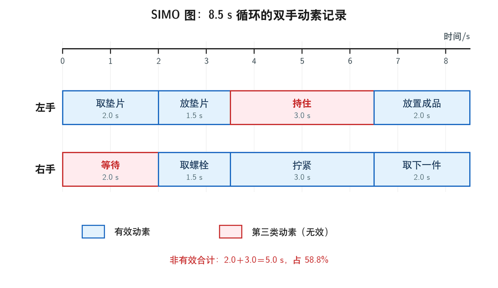

- **案例**：阀体装配，左手取放垫片、右手取螺栓并拧紧，原方法 8.5 s/件；左手在步骤 3 持住 3.0 s，右手在步骤 1 等待 2.0 s。
- **非有效合计 5.0 s（58.8%）**：持住是无效动素，用夹具替代；等待用“双手同时动作”消除。
- **改善**：夹具夹持，左右手同时开始、同时结束，周期 7.0 s，降 17.6%，产出提高 21.4%。
- **判据**：单手等待时间、持住时间、双手同时动作比例；双手同时动作会增加注意力负荷，精细作业要留余量。

## 动作分析：18 种动素与三类处理

| 类别 | 动素 | 处理原则 |
| --- | --- | --- |
| 第一类：有效动素（8 种） | 空运、握取、移物、装配、拆卸、使用、放手、检查 | 保留并简化 |
| 第二类：辅助动素（6 种） | 寻找、发现、选择、定位、预定位、计划 | 压缩并合并 |
| 第三类：无效动素（4 种） | 持住、休息、不可避免的延迟、可避免的延迟 | 消除或替代 |

- 动作分析是最细一层：把动作拆到不可再分的基本单元，逐项问“能不能去掉”。
- 第一类不等于增值（检查必要但不增值，仍要减少次数）；持住用夹具替代、寻找用定置替代、可避免延迟用平衡替代。
- 改善顺序：先消除第三类，再压缩第二类，最后简化第一类；判据是无效动素时间占比、动作次数与动作距离。

## 动作经济原则：身体、工作地、工具

| 方面 | 原则要点 | 现场做法 |
| --- | --- | --- |
| 身体使用 | 双手同时、对称反向、连续圆滑、利用惯性、节奏化 | 双手取放、U 型台面、脚踏 |
| 工作地布置 | 定置、按使用顺序、正常作业范围、重力送料、照明适宜 | 料架前置、滑道、工具形迹板 |
| 工具设备 | 夹具、脚踏、组合工具、省力手柄、机械化 | 气动夹具、电动螺丝刀、悬挂工具 |

- 原则可概括为四条：减少动作数、双手同时进行、缩短动作距离、使动作轻快省力
- 细化为 22 条（Barnes），按身体、工作地、工具三方面展开，不必背编号
- 身体方面：双手同时开始、同时结束；双臂对称反向；动作连续圆滑
- 工作地方面：工具物料定置，按使用顺序排列，放在正常作业范围内
- 工具方面：多用夹具与脚踏，减少持住；组合工具减少换取
- 应用顺序与 ECRS 一致：先取消动作，再合并、重排，最后简化
- 与 5S 的关系：定置管理是动作经济的工作地基础
- 判据：动作次数、动作距离、单手等待、疲劳程度

## 动作经济案例：工位改善

**案例**：某装配工位原单件 36.0 s，零件盒在身后 60 cm，螺丝刀在右后方。

| 问题 | 对应原则 | 对策 | 效果 |
| --- | --- | --- | --- |
| 料盒在身后 | 缩短动作距离 | U 型料架移到手边 25 cm | 取料 2.0→1.0 s |
| 螺丝刀在后 | 工具定置 | 悬挂式电动螺丝刀 | 取消转身 2×3.0 s |
| 目视对中 | 定位工装 | 定位夹具 | 装配 20.0→18.0 s |
| 成品放置 | 重力与滑道 | 滑道＋成品盒 | 放置 4.0→3.0 s |

## 节拍时间与瓶颈

> **承上**：上一页把标准时间定为“一件要多久”；这一页回答一条线按需求应该多快出一件、卡在哪道工序。

公式

$$T_{\mathrm{takt}}=\frac{T_{\mathrm{avail}}}{Q_{\mathrm{demand}}}$$

- **节拍由需求决定**，不是设备能跑多快：$T_{\mathrm{takt}}$ 为节拍时间（s/件）、$T_{\mathrm{avail}}$ 为每班可用生产时间（s）、$Q_{\mathrm{demand}}$ 为每班需求量（件）；算例：两班 960 min 扣 60 min 停机＝900 min、需求 600 件/天 → 90 s/件。
- **周期时间与瓶颈**：$CT$ 为某工序实际循环时间（s/件），只有 $CT\le T_{\mathrm{takt}}$ 才能满足需求；瓶颈是 $CT$ 最大的工序，产出 $=T_{\mathrm{avail}}/CT_{\max}$。
- **理论最少工位**：$N_{\min}=\left\lceil \sum t_i/T_{\mathrm{takt}} \right\rceil$（$t_i$ 为单件作业时间/s，$N_{\min}$ 为工位数/个）；例：总作业 1200 s、节拍 200 s → 6 个工位。
- **瓶颈会漂移**：改善后瓶颈会转移，必须重新识别；非瓶颈提效不增产，只增加库存与等待。
- **节拍随需求走、瓶颈随产线走**：每道工序都小于节拍才达产；需求一变，工位划分、人员与物流都要重算。

## 生产线平衡：平衡率与平滑指数

> **承上**：上一页由需求定出节拍、找到瓶颈；这一页回答整条线的负荷分得匀不匀、用哪两个指标衡量。

公式

$$E=\frac{\sum_{i=1}^{N}t_i}{N\cdot t_{\max}}\times100\%,\qquad SI=\sqrt{\frac{\sum_{i=1}^{N}(t_{\max}-t_i)^2}{N}}$$

- **符号与口径**：$E$ 为平衡率（%），$SI$ 为平滑指数（s），$t_i$ 为第 $i$ 工位工时（s），$t_{\max}$ 为瓶颈工时（s），$N$ 为工位数（个）；平衡损失率 $=1-E$；三条线总时间都是 300 s、6 工位。

| 产线 | 工位时间/s | 平衡率 | 平滑指数/s |
| --- | --- | --- | --- |
| A | 50、50、50、50、50、50 | 100% | 0 |
| B | 60、60、60、60、30、30 | 83.3% | 17.32 |
| C | 60、55、50、45、45、45 | 83.3% | 11.55 |

- **成对判读**：B 与 C 平衡率相同、$SI$ 相差 5.77 s，C 更均衡；$SI$ 越小越均衡，$E$ 看平均负荷、$SI$ 看离散程度。
- **边界与结论**：平衡率高不等于达产——瓶颈大于节拍仍欠产（工位取整、并行工位、换型停机还会拉低实际值）；$E$ 看平均浪费、$SI$ 看波动大小，两者要拿到瓶颈与节拍上一起比。

## 例题：线平衡现状计算（八工位） —— 题干与思路

**背景**：练由 8 个工位工时反推瓶颈、平衡率、平滑指数与产出。

| 工位：工序（时间/s） | 工位：工序（时间/s） |
| --- | --- |
| ① 装底座 50 | ② 装轴 40 |
| ③ 装齿轮 45 | ④ 装端盖 35 |
| ⑤ 拧紧 30 | ⑥ 接线 55 |
| ⑦ 自检 25 | ⑧ 贴标 20 |

- **求**：① 瓶颈 $t_{\max}$（s，整数）与总作业 $\sum t_i$（s，整数）；② 平衡率 $E$（%，1 位）；③ 平滑指数 $SI$（s，1 位）；④ 产出 $Q$（件/h，1 位）并与需求 60 件/h 比较（%，1 位）。

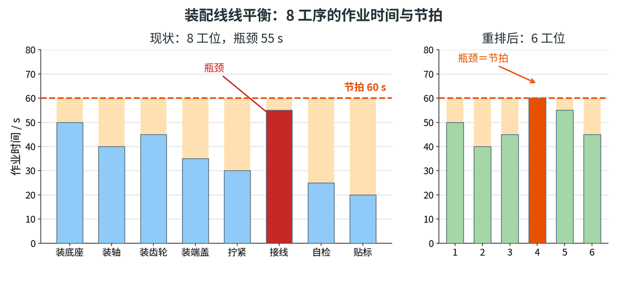

- **公式**：$E=\frac{\sum t_i}{N t_{\max}}$（$N=8$ 为工位数/个）；$SI=\sqrt{\frac{\sum(t_{\max}-t_i)^2}{N}}$（单位为 s）；$Q=3600/t_{\max}$（件/h）。
- **路线**：① 找最大值定瓶颈 → ② 求 $\sum t_i$ 与 $E$ → ③ 求各偏差平方和与 $SI$ → ④ 用 $t_{\max}$ 求产出、与需求比。

## 例题：线平衡现状计算（八工位） —— 分步解答

- **第 1 步 找瓶颈并校核总工时**：$t_{\max}=\max(50,40,45,35,30,55,25,20)=55$ s（接线）；$\sum t_i=50+40+45+35+30+55+25+20=300$ s。
- **第 2 步 求平衡率**：$E=300/(8\times55)=300/440=0.6818\approx68.2\%$；平衡损失率 $1-E=31.8\%$，按瓶颈算每循环空闲 $8\times55-300=140$ s。
- **第 3 步 求平滑指数**：偏差 $t_{\max}-t_i=5,15,10,20,25,0,30,35$ s；平方和 $=25+225+100+400+625+0+900+1225=3500$；$SI=\sqrt{3500/8}=\sqrt{437.5}=20.916\approx20.9$ s。
- **第 4 步 求产出并与需求比**：$Q=3600/55=65.45\approx65.5$ 件/h；需求节拍 60 s 即 60 件/h，超出 $(65.45-60)/60=9.1\%$。
- **判读**：平衡率 68.2%、$SI=20.9$ s 说明 8 个人的活没分匀；产出 65.5 件/h 已超需求 60 件/h——不是产能不足而是分配不匀，先重排、不急加人。
- **易错点/验算**：① 分母是 $N t_{\max}=440$ s，不是 $\sum t_i=300$ s；② $SI$ 单位是 s，先平方、求平均、再开方；③ 回算平方和 3500 ✓。

## 线平衡改进：ECRS 重排

| 指标 | 现状 | 改善后 | 变化 |
| --- | --- | --- | --- |
| 工位数/人 | 8 | 6 | -2 |
| 瓶颈时间/s | 55 | 60 | +5（等于节拍） |
| 平衡率 | 68.2% | 81.9% | +13.7 个百分点 |
| 平滑指数/s | 20.9 | 12.7 | -8.2 |
| 产出/(件·h⁻¹) | 65.5 | 60.0 | -8.3% |
| 人均产出/(件·h⁻¹) | 8.2 | 10.0 | +22.2% |

- E：取消独立贴标工位，标签随自检一起贴
- C：装端盖与拧紧合并，定位工装使装端盖 35→30 s
- C：自检与贴标合并，$25+20=45$ s
- R：按工艺顺序重排为 6 工位：50、40、45、60、55、45 s
- S：定扭矩工具、料盒前置，减少取放与走动
- 结果：8→6 人（降 25%），人均产出升 22.2%，产出回到需求节拍
- 风险：瓶颈 60 s 没有余量，需求一升就欠产；释放人员应转岗而非裁员

## 山积表：把整线负荷画成柱状

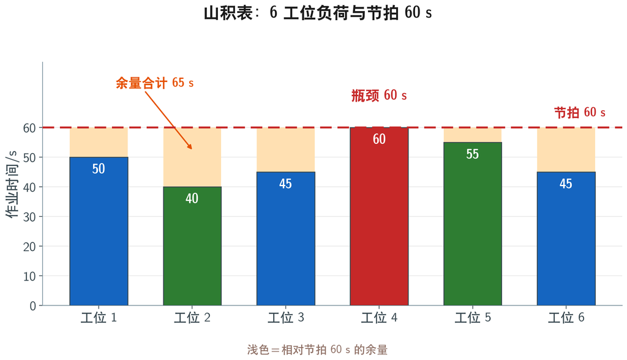

- 是什么：横轴工位、纵轴时间，柱高是负荷，红线是节拍
- 画法：按作业元素堆叠，柱高等于作业时间之和
- 本例：6 工位 50、40、45、60、55、45 s，总 295 s，节拍 60 s
- 读数：第 4 工位 60 s 顶到红线即瓶颈；空闲合计 $6\times60-295=65$ s
- 平衡率 $295/(60\times6)=81.9\%$，与线平衡率同口径
- 三条判据：哪根柱到线、哪根余量大、余量合计多少；改善是拆超线柱给余量大的柱，再复算平衡率
- 分工：组合票看单人循环，山积表看整线，两者不能互相替代

## 工位划分四步：从节拍到工位

**本页换用 6 元素小算例，与上两页的 8 工序案例不同源，专练分组。**

- ① 算节拍：需求与可用时间定节拍，本例 60 s
- ② 画元素与紧前关系：拆成不可再分的元素，标时间与先后
- ③ 按节拍组合：从首个元素起累加，不超节拍就并入同一工位
- ④ 校核：每工位不超节拍、紧前关系不违反、平衡率可接受
- 算例：6 个元素 30、25、40、35、20、15 s，总 165 s，理论最少工位 $\lceil165/60\rceil=3$ 个
- 分组：$30+25=55$、$40+20=60$、$35+15=50$ s；瓶颈 60 s，平衡率 $165/(60\times3)=91.7\%$
- 平滑指数 $\sqrt{((60-55)^2+(60-60)^2+(60-50)^2)/3}=6.45$ s
- 边界：元素不可拆时只能取整；分组后复核搬运次数与走动
- 与实验课的关系：手算定方案、整数规划模型验证最优

## 标准作业组合票：丰田做法

- 标准作业＝方法＋时间＋其他要求；三要素：节拍时间、作业顺序、标准手持
- 组合票：横轴时间、纵轴作业顺序，把一个循环的人、机、步行画在一起
- 本例：节拍 60 s，人工作业 38 s，步行 7 s，等待 15 s，自动加工 30 s

| 要素 | 图线 | 本例/s | 判读 |
| --- | --- | --- | --- |
| 人工作业 | 实线 | 38 | 取放、装配、拧紧 |
| 步行 | 波浪线 | 7 | 工位间移动 |
| 自动加工 | 虚线 | 30 | 与人工并行，不叠加 |
| 等待 | 空白 | 15 | 可再压缩 |
| 节拍 | 红线 | 60 | 循环基准 |

- 人工 38 s 加步行 7 s 等于 45 s，未越过 60 s 节拍线
- 越过节拍线必须拆作业、加人或改善工装；组合票看单人循环，山积表看整线
- 配套工位布置、行走路线、安全点与质量点，现场测时后绘制并随改善更新

## 推导留给 AI：程序分析与作业分析

- 用五种符号给“食堂打饭”或“快递分拣”画一张流程程序图，统计等待与搬运占比。
- 为什么先找瓶颈再消除等待？如果反过来，会出现什么后果？
- 平衡率 88.9% 的产线，瓶颈改善后为什么不一定能提产？列出三个约束。
- 查证：动作经济原则（Gilbreth）有哪些条目？哪些已经被自动化替代？

# 第三部分 · 精益生产

- 精益的由来、五个原则与 TPS 两大支柱
- 八大浪费：从过量生产到管理浪费
- 5S 与目视化；价值流分析 VSM
- 连续流、拉动与看板；均衡、SMED 与 TPM
- **承上**：上一部分把流程与生产线的效率算清楚了；本部分要回答哪些活动根本不增值、怎样让价值连续流动。

## 精益生产的起源：丰田、TPS 与大野耐一

- 20 世纪 50 年代，丰田在“多品种、小批量、缺资金”的约束下摸索新的生产方式
- 丰田佐吉的自动织机带来“异常即停”的思想，即带人字旁的**自働化**
- 丰田喜一郎提出**准时化**：只在需要的时候，按需要的量，生产需要的产品
- 大野耐一在车间把它落成一套系统，即 **TPS（丰田生产方式）**
- 两大支柱：准时化（JIT）与自働化；看板是准时化的神经
- 20 世纪 70 年代石油危机后，TPS 的抗风险能力被关注；80 年代中期欧美企业纷纷采用
- Womack 与 Jones 在《精益思想》中把丰田经验概括为五原则，“lean”由此通行
- 一句话：精益不是一套工具，而是“以更少做更多”的经营逻辑

## JIT 与自働化：TPS 的两大支柱

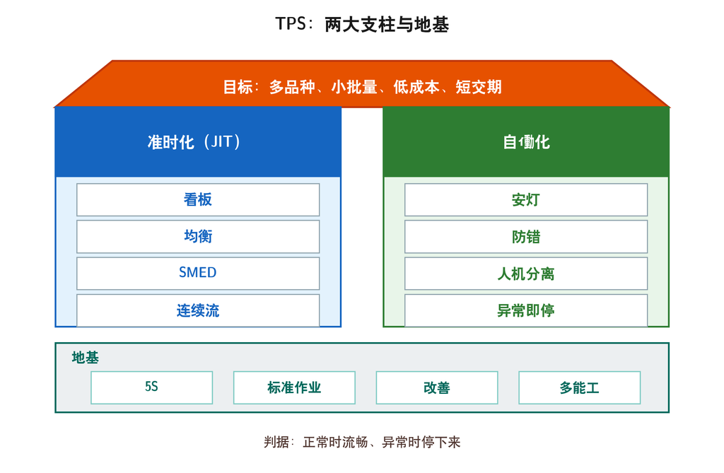

- **是什么**：TPS 的房子由两根柱子顶起来——准时化（JIT）管正常流，自働化管异常流
- **JIT 的四个抓手**：看板传递补货信号、均衡生产稳住节奏、SMED 压短换型、连续流把工序连起来
- **自働化**：丰田佐吉的自动织机“纬线一断就停”；人字旁的“働”提醒：自动化不等于无人化
- 判据：正常时流动、异常时停下来；缺自働化的 JIT 会把缺料直接传到下游

## 精益的核心：消除浪费与创造价值

- 精益干两件事：把价值做出来（流动），把不创造价值的去掉（消除浪费）
- 三个目标同步走：缩短交付周期、降低成本、改善质量，不靠互相牺牲换取
- 五个原则一线串：价值 → 价值流 → 流动 → 拉动 → 完美
- 关键特性：着眼于速度与简化，按需求平衡作业，没有订单不做

| 维度 | 大批量生产（福特） | 精益生产（丰田） |
| --- | --- | --- |
| 生产驱动 | 按预测推动 | 按订单拉动 |
| 批量 | 大批量、少品种 | 小批量、多品种 |
| 库存 | 用库存保连续 | 用流动替代库存 |
| 换型 | 换型慢、少换 | 换型快、勤换 |
| 布局 | 按工艺机群布置 | 按产品 U 型单元 |
| 人员 | 单一技能、专人专岗 | 多技能、少人化 |
| 供应商 | 多点压价 | 长期协同 |

## 价值与浪费：顾客视角的定义

- 价值的三个条件：顾客愿意付钱、改变产品的形态或功能、一次做对
- 增值工作只有四类：使物料变形、组装、改变性能、部分包装
- 浪费：超出“增加价值所必需的最低限度”的物料、设备、人力、场地与时间
- 同一条产线上其实有三类活动，对策完全不同

| 类别 | 判据 | 例子 | 对策 |
| --- | --- | --- | --- |
| 增值 VA | 顾客愿付钱、改变形态 | 切削、装配、焊接 | 压缩时间、提高稳定 |
| 必要非增值 NNVA | 当前必须做、不增值 | 检验、搬运、审批 | 创造条件让它不必要 |
| 纯浪费 NVA | 可立即去掉 | 等待、返工、寻找 | 立即消除 |

- 判据一句话：客户愿意为这个动作付钱吗
- 物料从进厂到出厂，增值时间往往不到 10%
- 两个陷阱：把“忙”当增值，把“必要”当“应该”

## 八大浪费总览：DOWNTIME 一张表

> **承上**：上一页从顾客视角把活动分成增值、必要非增值与纯浪费；这一页把纯浪费拆成可逐条识别的八类。
- **记忆钩子**是 **DOWNTIME**，但字母只是英文首字母，不要硬译成八个中文类别。
- **课本八类**：返工、过分加工、多余动作、搬运、库存、过量生产、等待、管理浪费；N 位英文是 Non-utilized talent（人才未利用），≠管理浪费，考试按课本八类作答。

| 缩写 | 浪费 | 主要危害 | 典型根因 |
| --- | --- | --- | --- |
| D | 返工 | 材料、工时损失 | 没有完整的质量体系 |
| O | 过量生产 | 积压、占资金 | 固定批量、以量保质 |
| W | 等待 | 人闲、机停 | 线不平衡、缺料 |
| N | 人才未利用（考试按课本口径作“管理浪费”） | 问题无人决策 | 激励机制失灵 |
| T | 搬运 | 等待、占空间 | 现场布局不合理 |
| I | 库存 | 多搬运、贬值 | 过量生产、信息失真 |
| M | 多余动作 | 疲劳、易工伤 | 动作设计与工位不合理 |
| E | 过分加工 | 多耗工时能耗 | 流程与工艺设计不当 |

- **排序**有争议，但过量生产被普遍视为最坏的一种：它同时制造并掩盖其他浪费。

**结论：先判“顾客愿不愿付钱”，再用 DOWNTIME 查全；根因多在系统。**

## 浪费一：过量生产是最坏的浪费

- 定义：生产多于所需、快于所需，或早于所需
- 三种形态：多产（数量超）、早产（时间提前）、大批量（一次做太多）
- 为什么最坏：它把等待、库存、搬运、不良一并制造出来，还把它们藏起来
- 代价算例：月需求 10 万件、单价 50 元、超产 10% → 占用资金 50 万元
- 资金成本按 6%/年计 → 3 万元/年，尚未计入仓储、贬值与二次搬运
- 心理根源：“以防万一”的心态，加上“设备不能闲着”的考核
- 对策：拉动生产、小批量、缩短换型、按节拍投料
- 一句判据：后工序没有消耗，就不该生产

## 浪费二：等待

- 三种等待：人等机、机等人、人等料（含等检验、等指令）
- 根因：线不平衡、换型与故障、物料不齐、计划脱节、信息不畅
- 量化三张成绩单：线平衡率看人、可用率看机、齐套率看料
- 代价算例：10 人、每班等 30 min、250 班/年 → 1250 人·时
- 按 30 元/时计 → 3.75 万元/年，尚未计入交付延迟的损失
- 对策：平衡工序、SMED、TPM、齐套投料、异常快速响应
- 注意：大批量会把等待藏进在制品里，看上去像“大家都在忙”

## 浪费三：搬运

- 定义：不改变产品形态的物料移动，移动本身不增加价值
- 三个量化指标：次数、距离、占用工时（含装卸与等待）
- 算例：每班 40 次、单程 25 m、往返 → 2 km/班；250 班 → 500 km/年
- 每次 8 min → 320 min/班 ≈ 5.3 h/班 → 1333 h/年
- 危害不止工时：磕碰、混料、找料、通道占用、安全风险
- 对策顺序：取消（不要搬）→ 合并（顺路带）→ 重排（近置）→ 简化（器具）
- 布局是根：按工艺机群布置必然反复搬运，按产品 U 型单元可大幅减少

## 浪费四：过分加工

- 定义：超出客户需求的功能、精度、步骤与检验
- 常见表现：公差一味收紧、多余倒角与打磨、重复录入、全检代替过程控制
- 判断依据是客户规格与真实使用要求，而不是“越高越好”
- 算例：单件多花 4 min，年产 5 万件 → 20 万 min ≈ 3333 h
- 按 60 元/h 计 → 20 万元/年，尚未计入设备折旧与能耗
- 根因：设计冗余、工艺保守、标准过时、怕担责层层加码
- 对策：价值工程与公差分析、工序合并、以防错替代全检、定期复核标准

## 浪费五：库存掩盖所有问题

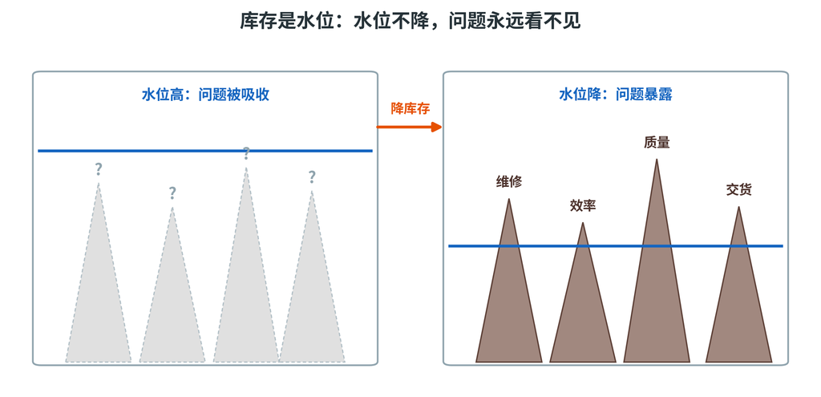

- **是什么**：库存像水位、问题像礁石——水位高时，设备、效率、质量、交货问题都被库存吸收
- **怎么判断**：算周转天数与在制品数量；再问“库存减半，哪一环先停”，答案就是最该改的地方
- **怎么做**：降一档 → 暴露 → 解决 → 再降一档，不能一次降到底

## 浪费六：多余动作

- 定义：人或设备的任何不增加产品价值的动作
- 常见形态：两手空闲、单手空闲、动作过大、转身过大、弯腰、寻找、重复抓取
- 量化：动作次数 × 单次时间；录像分析比凭记忆可靠
- 算例：每班弯腰 300 次、每次 2 s → 10 min/班；250 班 → 41.7 h/年
- 料架抬高后每次 0.5 s → 2.5 min/班，每班省下 7.5 min
- 危害还有疲劳与职业伤害，这是“人”的成本，不只是工时
- 对策：动作经济原则、工位与料架改造、U 型布置、工装化与双手作业

## 浪费七：返工

- 定义：不良品带来的返工、报废、复检、让步与客户索赔
- 代价四块：材料、工时、检验与追溯、交付与信誉
- 算例：日产 1000 件、不良率 2% → 20 件/日
- 返工 15 min/件 → 300 min/日，工时费按 30 元/h 计为 150 元/日
- 材料 30 元/件 → 600 元/日；合计 750 元/日 → 18.75 万元/年（250 日）
- 越晚发现越贵：1-10-100 法则，工位、总装、客户三档代价递增
- 对策：三不政策、防错、SPC 与过程能力、源头止住而不是靠全检兜底

## 浪费八：管理浪费——最贵的浪费不上账

> **同样的问题第二次出现，就是管理浪费。**
- **定义**：不直接改变产品、却消耗时间与信任的管理活动——决策慢、协调内耗、推诿、报表与审批过量。
- **现场表现**：异常单卡在主管桌上、跨部门扯皮、会议与报表替代了解决问题、审批环节层层加码。
- **量化三个数**：决策等待天数、审批环节数、同一问题的重复沟通次数；管理浪费难以直接折算工时，但代价落在上下工序与一线。
- **根因**：激励机制失灵、人岗不匹配、权责不清、只考核不授权。
- **对策**：责任到人、决策时限、授权边界、异常可视化跟踪；把“谁在等谁”画进流程程序图。
- **伦理钩子**：管理浪费的代价往往由一线与下工序承担（接第 9 讲“组织责任模糊化”）。

## 现场识别浪费的五个方法

- 识别浪费要靠证据，不靠感觉；五个方法各管一段，组合起来才完整

| 方法 | 怎么做 | 产出 | 局限 |
| --- | --- | --- | --- |
| 观察 | 沿物料流走查，先记事实不先问原因 | 现场问题清单 | 只看得到当下 |
| 流程 | 程序分析、流程程序图、VSM | 断点与库存点 | 画图费时 |
| 数据 | OEE、平衡率、周转、返工率 | 量化排序 | 数据本身可能失真 |
| 访谈 | 问操作者与上下游，用 5Why 追根 | 根因与经验 | 带主观情绪 |
| 标杆 | 比兄弟线、行业、历史最好 | 目标与差距 | 口径要一致 |

- 组合用法：先观察与流程找线索，再用数据定量，最后访谈找根因
- 输出一张浪费清单：位置、数量、金额、责任人、期限，缺一项就不算识别完成

## 5S：内容与目的

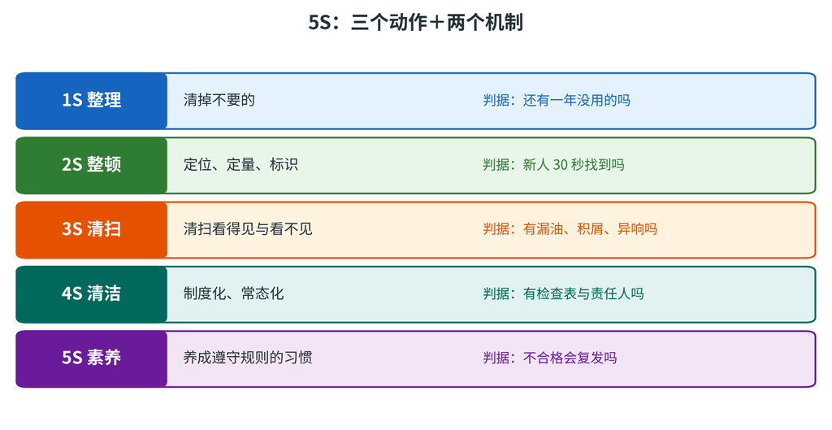

- **是什么**：5S＝三个动作（整理、整顿、清扫）＋两个机制（清洁、素养）；前 3S 改现场，后 2S 改习惯
- **怎么判断**：整理看一年未用之物，整顿看 30 秒能否找到并归位，清扫看漏油积屑，清洁看责任人与频次
- **素养与扩展**：素养看检查不合格会不会复发；6S／7S 加安全与节约，考试按 5S 答
- 顺序不能跳：不整理就整顿，等于把垃圾摆整齐

## 5S 推行六步与评分检查表

- 六步：成立推行组织 → 培训宣导 → 红牌作战（整理）→ 三定与目视化（整顿）→ 清扫点检与发生源对策 → 制度化与审核评比
- 两个抓手：红牌清物、定点摄影留证；配套工具是区域线、色标、点检表、班组晨会
- 检查表按要素打分，每项 20 分，五项满分 100 分

| 检查项 | 评分要点 | 分值 |
| --- | --- | --- |
| 地面与通道 | 无杂物积水、区域线清晰 | 20 |
| 工具与工装 | 定位摆放、形迹板齐全 | 20 |
| 物料与在制品 | 定量标识、先进先出 | 20 |
| 设备清洁 | 无油污积屑、点检按时 | 20 |
| 素养与遵守 | 按标准作业、按规定点检 | 20 |

- 判级：90 分以上优秀，70～89 分合格，70 分以下限期整改
- 关键在闭环：评分有人签字、整改有期限、下轮复核并公示

## 5S 审核实操：红牌与定点摄影

- **是什么**：红牌作战把现场“不要的东西”逐件挂牌、限期处置；定点摄影用同一机位反复拍
- **一次作战**：30 张红牌，处置 24、延期 4、转固定资产 2，平均处置 5.2 天
- **闭环率**：24/30=80%，延期 4 张进下一轮跟踪，不能挂完就算完
- **定点摄影**：18 组照片，固定机位、同角度、同焦段，前后对比才可信
- **复发**：下轮复查复发 3 处，复发点就是审核重点，不能只怪员工不守规矩
- **效果**：寻找时间 45→20 s，5S 的收益要落到时间与安全上
- **分层审核**：班组日、主管周、厂长月，三级都看现场不看报表
- 判据：闭环率 80% 以上、复发率下降、寻找时间缩短，三条一起看

## 价值流分析 VSM：看整条流

> **承上**：上一页的八大浪费是逐条识别；这一页把产品从原材料到交付的全部活动画成一张图，回答浪费发生在哪一段。

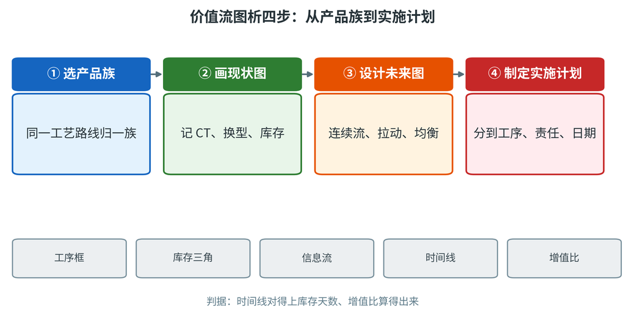

- **是什么**：VSM 把产品从原材料到客户、从概念到投产的全部活动（增值与非增值）画在一张图上。
- **四步与判据**：选产品族 → 画现状图 → 设计未来图 → 制定实施计划；只有时间线对得上库存天数、增值比算得出，才算画对。
- **图上五要素**：工序框（$CT$ 周期时间/s、$C/O$ 换型时间/min、Uptime 可用率/%）、库存三角（数量/件、可支撑天数/天）、信息流、时间线（增值时间/min、非增值时间/天）、增值比（$=T_{\mathrm{VA}}/T_{\mathrm{LT}}$，$T_{\mathrm{VA}}$ 增值时间/min、$T_{\mathrm{LT}}$ 交付周期/min）。

**结论：VSM 的诊断价值在时间线上——加工只有几分钟、等待却以天计，改善对象是那些“天”，不是机器转得更快。**

## VSM 的读法与增值比

- 时间线分两段：增值时间（工序加工）与非增值时间（库存等待、搬运）
- **增值比**＝增值时间 ÷ 交付周期
- 算例：增值时间 2.4 min，交付周期 5 天 ×8 h＝2400 min → 增值比 0.1%
- 读法：先看哪段库存最长、哪道工序是瓶颈，再定改善优先级
- 结论：改善空间主要在非增值时间，而不是“让机器转得更快”

## 价值流图 VSM：符号与画法

- 先画物料流，再画信息流，最后补时间线；一张图只画一个产品族

| 符号 | 含义 | 画法与填写 |
| --- | --- | --- |
| 工厂图标 | 客户与供应商 | 左上供应商、右上客户 |
| 工序框 | 一道工序 | 框下写 CT、C/O、Uptime、批量 |
| 库存三角 | 工序间库存 | 写数量与可支撑天数 |
| 推动箭头 | 按计划推动 | 条纹粗箭头 |
| 超市与看板 | 拉动补货 | 超市符号加看板小方块 |
| 信息流 | 计划与指令 | 直线为手工、折线为电子 |
| 时间线 | 增值与非增值 | 上阶写天数、下阶写秒数 |

- 画法三律：从右向左画，数据现场实测，不抄标准工时
- 常见错误：把图画成工艺流程图，只画物不画信息与时间

## VSM 案例：从现状图到未来图（一）

**现状图**：冲压→焊接→涂装→装配→检验包装，工序间都有库存。

| 工序 | CT/s | 现状库存/天 |
| --- | --- | --- |
| 冲压 | 60 | 2.0 |
| 焊接 | 45 | 3.0 |
| 涂装 | 30 | 2.0 |
| 装配 | 50 | 2.5 |
| 检验包装 | 40 | 1.5 |

- 增值时间＝ΣCT＝225 s；等待时间＝Σ库存＝11 天
- 交付周期＝11 天＋225 s；按 480 min/天折算，增值比＝$225/(11\times480\times60)\approx0.07\%$
- 库存天数＝库存量/日需求，现场量出来，不能凭经验估
- 时间线上台阶是库存天数、下台阶是加工时间，一眼看出等待在哪
- 价值几乎全在等待，不在加工；要缩交期，先削库存，不是先提加工速度

## VSM 案例：从现状图到未来图（二）

| 工序 | 现状库存/天 | 未来库存/天 | 未来做法 |
| --- | --- | --- | --- |
| 冲压 | 2.0 | 0.5 | 超市拉动、小批量 |
| 焊接 | 3.0 | 1.0 | 与冲压连成连续流 |
| 涂装 | 2.0 | 1.0 | 缩短换型、减小批量 |
| 装配 | 2.5 | 1.0 | 单件流、U 型单元 |
| 检验包装 | 1.5 | 0.5 | 过程内检验、取消终检 |

- 未来：连续流加超市拉动，库存 11→4 天，交付周期缩短约 64%
- 增值比升到 $225/(4\times480\times60)\approx0.20\%$，产能不变而交期更短
- 不能连成连续流的冲压、涂装，用超市拉动隔离
- 未来图四问：节拍多少、哪里建超市、哪里连续流、哪里设投放点
- 落地：每条改善写清责任人与期限，否则未来图只是画得好看
- 未来图画完要重画现状图，作为下一轮改善的基准

## 交付周期与制造周期：口径先分清楚

> 上一页把交期从 11 天压到 4 天；这一页先分清：那条时间线算的是交付周期，还是制造周期。
- **LT（Lead Time，交付周期）**：订单→订单处理→采购→物料进厂→加工→发货→货款交付，顾客从下单到收齐货的全过程
- **MCT（Manufacturing Cycle Time，制造周期）**：物料进厂→加工→成品出厂；恒有 $MCT\le LT$，差额在信息段与采购等待
- **VSM 口径**：时间线从物料进厂算到成品出厂，量的是 MCT；上一页的 11 天＋225 s 属 MCT，不是 LT
- **折算**：$225/28800=0.0078$ 天，$MCT=11.008$ 天；设订单 2 天、采购 5 天、收发货款 3 天，$LT=21.008$ 天，$MCT/LT=52.4\%$

| 段 | 含哪些环节 | 缩短手段 |
| --- | --- | --- |
| 信息段 | 订单处理、回款 | 电子订单、按里程碑开票 |
| 等待段 | 采购、库存、排队 | 供应商管理库存、超市拉动、削库存 |
| 制造段（MCT） | 加工、工序间搬运 | 连续流、快速换模、线平衡 |

**结论：交期承诺按 LT、改善能力看 MCT；报哪个数都必须写清口径，别把 MCT 的改善当成 LT 的成果。**

## 连续流与单件流：从批量到流动

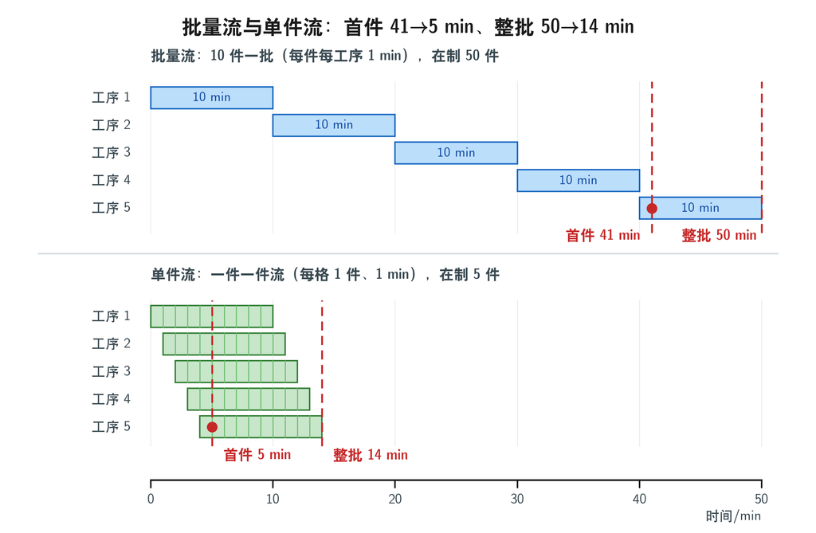

- **是什么**：连续流＝一件一件按工序顺序流动，工序之间不堆在制品
- **批量流的账**：批量 10 件、5 道工序、每件每工序 1 min，首件 41 min、整批 50 min、在制约 50 件
- **单件流的账**：同样条件下首件 5 min、整批 14 min、在制 5 件
- **连续流三条件**：按产品族布局、换型足够短、质量稳定（一次通过率高）
- 冲压、涂装这类不能硬连的环节，用超市拉动隔离，不要为流动而流动
- 注意：单件流不等于每件都换型，一次通过率低时先做质量再做流动

## 拉动式生产：从推动到超市补货

- 推动：按计划把料推给下工序，计划一错就变成库存
- 拉动：后工序消耗多少，前工序补充多少，信号来自消耗本身
- 单点节拍控制：只在总装设定节拍，其余环节由看板连锁
- 三种拉动信号：双箱法、卡片或容器、电子看板

| 对比项 | 推动式 | 拉动式 |
| --- | --- | --- |
| 依据 | 计划与预测 | 后工序的消耗 |
| 库存 | 各工序自备缓冲 | 超市定量、超量不补 |
| 异常 | 被库存掩盖 | 立即暴露、立即停线 |
| 计划 | 集中排产、层层下达 | 由看板触发的局部补货 |

- 前提：节拍平衡、质量稳定、换型短、物流路线清晰，四条缺一不可
- 与信息系统结合：看板电子化后，补货信号可以自动传递

## 看板种类、六条规则与数量

| 种类 | 用途 | 走法 |
| --- | --- | --- |
| 工序看板（IPK） | 指示本工序生产 | 随容器流动，容器空了才生产 |
| 取料看板 | 指示后工序去取料 | 随取料动作回传前工序 |
| 信号看板 | 触发批量生产 | 成批使用，达到批量才开工 |

- 六条规则：无看板不生产不搬运；后工序只取所需；前工序只补被取走；看板随实物走；不良品不流入下工序；逐步减少看板数。
- 看板数由需求、补货周期、安全系数与容器容量决定：$N=\dfrac{D\,L\,(1+\alpha)}{C}$；算例 600 件/日、1 日、10%、20 件/箱 → 33 张。
- 减卡不是省纸，是过程能力提高后用更少库存撑同样交付：L 由 1 日降到 0.9 日 → 29.7 取 30 张；换型改善 L=0.75 → 24.75 取 25 张；α 降到 5% → 23.625 取 24 张，一律向上取整。
- 判据：减卡后缺料停线次数不升反降才算真减；减不动处就是下一个改善点。

## SMED：快速换模的八步法

- 换型时间：上一型号最后一件合格品，到下一型号第一件合格品
- 两类作业：内部（必须停机才能做）、外部（不停机可做）
- 核心动作是把内部作业转为外部作业：备料、预热、找工具都提前做
- 八步：观察、记录、区分内外部、分析动作、内转外、优化、试验、标准化
- 技术手段：快速夹紧、定位销与限位、标准工装、并行作业
- 算例：换型 90 min、批量 60 件、单件 1 min → 换型相当于纯生产时间的 150%
- 降到 25 min → 41.7%；经济批量由 537 件降到 283 件，库存随之减半
- 常见错误：只买快换夹具，不改作业流程与标准，换型时间降不下来

## SMED 换模分解：90 min 里哪些能外移

- **是什么**：把换型动作逐项记录，先分内、外两类，再按外移、压缩、并行三步做
- 原 90 min 中，拆模 20、装模 25、对刀 25 全是内部作业，合计 70 min 停机
- 改善后内部只剩 8+10+7=25 min，找工具与清理归零
- **与批量的关系**：经济批量随换型时间的平方根下降，25 与 90 之比的平方根约 0.53
- 判据：内部时间占换型总时间的比例，越低越好；内转外可能引入新安全风险，要同步改作业标准

| 项目 | 原/min | 内/外 | 改善动作 | 改善后/min |
| --- | --- | --- | --- | --- |
| 找工具 | 15 | 外 | 工具车备齐、换型清单 | 0 |
| 拆模 | 20 | 内 | 快换夹紧 | 8 |
| 装模 | 25 | 内 | 定位销与限位 | 10 |
| 对刀 | 25 | 内 | 预设对刀块、首件免调 | 7 |
| 清理 | 5 | 外 | 停机前清理 | 0 |
| 合计 | 90 | — | — | 25 |

## 均衡生产与混流排产

- 均衡两件事：数量均衡（每天总量平稳）与品种均衡（每天配比平稳）；均衡不是平均主义，是按客户真实配比排产。
- 算例：日需求 A 240 件、B 120 件、C 120 件，合计 480 件；可用 480 min → 节拍 60 s。
- **批量排法**：A 做完再做 B、C，换型 2 次共 20 min，账上最省；代价是成品与在制积压、交期与库存变差。
- **混流排法**：4 件一循环按 A-A-B-C，全天 120 个循环，成品库存几乎为零。
- **换型账**：混流每循环 3 次换型 ×120＝360 次；按 10 min/次＝3600 min，远超 480 min 可用时间。
- 设单件加工 $p$、换型 $c$：须 $480p+360c\le480$；$p=0.25$ min（15 s）时 $c\le1$ min。
- 结论：先做 SMED 再谈混流；判据看成品库存、换型次数与交付达成。

## 设备与指标：TPM 与 OEE

- TPM：全员参与，以自主保全与计划保全追求设备的极限效率
- 八大支柱：个别改善、自主保全、计划保全、教育训练、初期管理、品质保全、事务改善、安全环境
- 六大损失：故障、换型调整、空转短停、速度降低、废品返工、起动试产
- OEE 把六类损失折算成三个率

| 阶段 | 时间/min | 本段损失 |
| --- | --- | --- |
| 可用时间 | 450 | — |
| 故障与换型 | 340 | 110 |
| 小停与减速 | 248 | 92 |
| 废品与起动 | 228 | 20 |

- 时间开动率 $340/450=75.6\%$，性能开动率 $248/340=72.9\%$，合格品率 $228/248=91.9\%$
- $OEE=0.756\times0.729\times0.919\approx50.7\%$，世界级水平约 85%
- 维修指标：MTBF、MTTR，预防维护时间占比目标 70% 以上

## 精益的数字化接口：MES 与精益

- 精益提供“改什么”（浪费识别与改善原则），MES 提供“改得怎么样”（实时数据与追溯）
- MES 采集设备与人员动作数据，自动统计停机、节拍、在制品
- 与 WMS 结合优化库存，与 PLM 结合把 FMEA 与防错固化到工艺
- 改善闭环：发现浪费 → 设定目标 → 措施上线 → 数据验证 → 标准化
- 注意：数据采集本身不是目的，不能为了报表而采集

## 精益实施路线与常见失败

- 五段路线：危机意识与高层承诺 → 规划与数据 → 试点 → 全面推广 → 持续改进
- 时间尺度：试点约 12 周，第一个全覆盖车间半年到一年，全厂 4～5 年
- 培训比例：约 10% 的人需要系统训练，关键流程主管需进阶训练
- 失败一：只上工具（5S、看板）不改考核，改善被 KPI 拉回原样
- 失败二：无激励、无愿景、无计划、无技能、无资源，缺一项就半途而废
- 失败三：过程不稳就上拉动，停线后回退，结论是“精益不适合我们”
- 顺序建议：5S 与目视化 → 稳定与 TPM → SMED → 连续流 → 看板拉动
- 判断标准：改善有没有变成新标准，标准有没有人守

## 推导留给 AI：精益生产

- 八大浪费中，哪一类最难量化？为它设计一个可测量的指标。
- 库存降低会依次暴露哪些问题？按暴露顺序排一个清单。
- VSM 的增值比为什么常常低于 1%？这是否意味着改善空间巨大？
- 查证：精益五原则（Womack & Jones）的原文表述与中文译法差异。

# 第四部分 · 现场改善与人的关系

- 三现与五现、Gemba 改善；标准作业与目视化
- 防错（Poka-Yoke）与防呆管理流程
- 人机工程、劳动强度与工作设计；多能工与轮岗
- 伦理落点：效率与人的关系
- **承上**：上一部分从流程与浪费看整条流；本部分要回答改善怎样在现场固化、人的因素怎样写进方案。

## 三现与五现：到现场、看现物、按原理

- **三现**：现场（问题发生地）、现物（有关实物）、现实（真实状态与数据）；再加原理（科学规律）与原则（对策规则），合称**五现主义**
- **现场**＝实际发生行动的场地；制造企业的现场指制造产品或提供服务的地方；现场管理对象：人、机、料、法、环、资、能、信
- 现场的第一手信息最完整：汇报每转一层，异常细节就少一层
- 到现场做三件事：看状态与动作、问操作者怎么想、测数据核实
- 反例：在会议室凭报表定措施，问题常被“改”到下一个工位
- 判据：措施能否在现场被验证——谁、何时、用什么数据
- 与 PDCA 的关系：C 阶段必须回现场，否则检查的是报表而不是事实
- 结论：现场是唯一能验证假设的地方，办公室只能验证说法

## 改善的内涵与目标：QCDMS 五字诀

> 上一页讲怎么到现场取证；这一页回答取完证改什么、按什么算“变好了”。
- **改善是什么**：小步伐改进的逐次累积，不是等一次大改革；过程为导向——改过程才改结果
- **QCDMS 五目标**：质量 Q、成本 C、交付 D、士气 M、安全 S；五者同时不恶化，不是拿一个换四个
- **质量第一**：不把不合格品与错误信息流给下一流程——下一流程就是顾客，这条排在“快”前面
- **用数据说话**：先搜集现状资料作改善出发点；没有基线与口径的改善，只是把意见说得更肯定
- **改善与管理**：管理维持标准、改善提升标准；只维持会退，只改善不维持会回到原状

| 目标 | 问什么 | 常见反例 |
| --- | --- | --- |
| Q 质量 | 一次通过率、不良率变了吗 | 提节拍换来返工 |
| C 成本 | 总成本降了吗 | 只算人工单价 |
| D 交付 | 交期与准交率变了吗 | 靠堆库存换“快” |
| M 士气 | 员工还愿意提提案吗 | 提案三个月不回复 |
| S 安全 | 风险与劳动强度变了吗 | 省动作省出伤害 |

**结论：改善是 QCDMS 五项在约束下的更优组合；判据是说清五项得失、指出用哪份数据在什么时限内验证，单项赢了就是别处欠账。**

## Gemba 改善与现场 PDCA

- 金科玉律：去现场→检查现物→当场暂行处置→追查真因并排除→标准化防止再发
- P：选定问题、调查现状、定目标与原因，全部用数据说话
- D：小范围试行——一条线、一个班次，不全面铺开
- C：用同一口径的数据对比，并回现场确认，防止“报表改善”
- A：有效就标准化，写进作业指导书；无效就修正假设再循环
- 大环带小环：公司方针→部门目标→班组课题，层层有 PDCA
- 改善与维持：PDCA 负责提升，SDCA 负责守住；只提升不维持，成果会随人员流动退回去
- 判据：每一轮是否留下“标准＋数据＋责任人”

## 标准作业与作业标准：把方法写下来

- 工作标准（作业标准）＝标准作业法＋标准时间＋其他要求（质量、安全、工装）
- 标准作业三要素：节拍时间、作业顺序、标准手持
- 作业指导书三栏：步骤（做什么）、要点（怎么做）、理由（为什么）
- 标准来自方法研究与作业测定，不是在办公室里编出来的
- 可执行的标准：图、照片、限度样本、判定基准，少用长段文字
- 修订：改善确认后立即改标准，旧版回收，避免两个版本同时在场
- 培训：按标准培训、考核上岗，标准同时是培训教材
- 常见失败：标准挂墙上、版本混乱、操作者没参与编写
- 一句话：没有标准就没有改善，因为无法判断“改好了没有”

## 改善提案：制度与实例

- 目的：把“知道问题的人”变成“能改的人”；提案闭环六步——提出 → 受理 → 评价 → 实施 → 奖励 → 标准化，缺一环就断。
- 评价维度：效果、创新性、可推广性、投入与风险；时效 30 天内答复、60 天内实施，好提案必须进标准。
- 三个失败：只收不用、只奖大事、上级署名。

| 提案 | 问题 | 措施 | 收益 | 状态 |
| --- | --- | --- | --- | --- |
| 料盒前置 | 寻找 6 s/次、600 件/班 | 料盒前置并斜置 | 省 40 min/班 | 已实施 |
| 脚踏开关 | 弯腰 300 次/班 | 脚踏夹紧 | 弯腰 300→0 次/班 | 已实施 |
| 快换夹具 | 换型 45 min/日 4 次 | 定位销＋快换夹紧 | 省 100 min/日 | 已实施 |
| 看板电子化 | 缺料停线 3 次/周 | 扫码触发补货 | 停线 3→0.5 次/周 | 实施中 |
| 防错装置 | 漏装 3 件/月 | 计数＋传感器即停 | 漏装 3→0 件/月 | 已实施 |

- 判据：员工能否说出本班组本月的一项改善和自己的一件提案；不实施的提案比不提更伤士气。

## 目视化管理、定置与安东

| 工具 | 做法 | 判据 |
| --- | --- | --- |
| 地面划线、区域牌 | 通道、原料、在制、成品分区，黄线定界 | 新人能独立找到位置 |
| 工具形迹板 | 每件工具有固定轮廓，缺件一眼可见 | 工具齐套可点检 |
| 安灯（Andon） | 异常拉灯，颜色区分缺料、质量、设备 | 异常能快速响应 |
| 看板、绩效板 | 小时产量、节拍、异常记录 | 偏差当班可见 |
| 库存上下限标识 | 最高、最低库存线，超线报警 | 库存不超上限 |

- 目视化三问：谁看、看什么、看了做什么；每条信息都要绑定反应计划、责任人与时限。
- 定置三定：定点、定容、定量，让“东西在哪”不依赖记忆；先定物品与数量，再定位置与标识。
- 安东的成败在响应：黄灯求援、红灯停线，关键是“拉灯不被骂”，否则员工宁愿把不良品流下去。
- 判据：新人到工位能否自己判断“正常还是异常、下一步做什么”。

## 防错：错误、缺陷与防呆设计准则

- **错误**＝与预期的偏离（疏忽、遗忘、误解……）；**缺陷**＝错误造成的后果
- 常见错误类型：漏工序、用错工具、漏装零件、装错零件、误操作……
- 错误的九类原因中，人的因素占七类（77.8%）——防错要针对人因设计
- 四条设计准则：简化流程；降低对技能与直觉的依赖；消除安全隐患；降低对感官的依赖
- 防呆的层次：提示（报警）→ 限制（做不对就装不上）→ 根除（设计上不可能做错）

## 防呆管理流程与防错五步

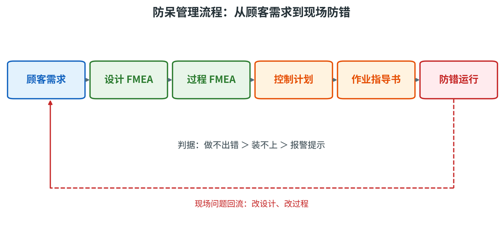

- **一条链**：顾客需求 → 设计 FMEA → 过程 FMEA → 控制计划 → 作业指导书 → 现场；设计改一处，比末端加十道检查便宜。
- **五步法**：识别问题 → 分优先级 → 找根本原因 → 产生办法 → 衡量结果。
- **两条回路**：过程防错→过程修改→回到 FMEA；现场错误清单→改设计、改过程。
- **风险**：装置增加操作者负担会被绕过；能短接的装置等于没有；防错是设计出来的，不是要求人更小心。

## 防错三则：装置、信号与流程

- **是什么**：三个案例分别落在防错三个层次——提示、限制、根除
- **定位销不对称**：销距与偏置做成只有正确方向装得进，装反做不出来（根除）
- **扭矩枪灯光与声音**：到位亮绿灯、给声音，漏拧与扭矩不足当场暴露（提示）
- **扫码放行**：不扫码工位不放行，漏工序与错料流不走（限制）
- **选择顺序**：根除优于限制，限制优于提示；提示靠人，最不可靠
- **三条判据**：做不出（根除）、流不走（限制）、发现得了（提示）
- 注意：增加负担的防错会被短接——装置让人变慢，人就会想办法绕过去
- 设计要点：装置要省动作而不是添动作，最好也不依赖人的注意力

| 案例 | 防什么错 | 原理层次 | 代价与局限 |
| --- | --- | --- | --- |
| 定位销不对称 | 底座装反 | 根除：装不进 | 要改工装，换型要换销 |
| 扭矩枪灯光与声音 | 漏拧、扭矩不足 | 提示：异常立现 | 依赖人看灯，需点检 |
| 扫码放行 | 漏工序、错料 | 限制：不扫码不放行 | 系统维护，条码易污损 |

## 人机工程学与作业姿势

| 维度 | 人擅长 | 机器擅长 |
| --- | --- | --- |
| 信息感知 | 发现不常出现的异常，抗干扰 | 感知范围大，但不加选择 |
| 信息处理 | 推理、创造、简化复杂信息 | 快速运算、大容量记忆 |
| 信息输出 | 灵活、可应变，但力气小、易疲劳 | 功率大、持续、重复精度高 |

- 定义：研究人、机器、环境的关系，设计最佳的人机环境系统；三条设计线——显示器（信息输入）、操纵器（动作输出）、作业空间（可达范围）。
- 人机功能分配按上表界限分工，不是“能自动就全自动”；环境（温度、湿度、照明、噪声、振动、粉尘）都要进入设计。
- 作业姿势四类典型负荷：静态保持、弯腰、扭转、手臂过肩；力臂效应——手持 2 kg 工具、前伸 0.4 m 时肩部力矩 7.8 N·m，前伸缩到 0.25 m 降到 4.9 N·m。
- 改进顺序：先消除动作，再改工位与工装，最后才靠培训提醒；判据是让机器与环境适应人，而不是让人去适应设计。

## 人机工程数据：作业范围与台面高度

- **是什么**：把作业范围与台面高度变成一组可以直接量、可以直接改的数
- **三条原则**：常用件放正常范围、重件不高举、能滑动不搬起
- **台面高度按作业性质分**：精密偏高、用力偏低、坐姿再低
- **判据**：取放不用转身、不用弯腰、不用过头，一眼看到、一手拿到
- 注意：以上为常用设计值，现场以实测与标准为准，身高不同要能调

| 项目 | 常用设计值 | 说明 |
| --- | --- | --- |
| 正常作业范围 | 前臂可达 35–45 cm | 常用件放这里 |
| 最大作业范围 | 55–65 cm | 少用件才放这里 |
| 站立精密作业台面 | 95–105 cm | 肘下 5–10 cm |
| 站立用力作业台面 | 85–90 cm | 靠体重与躯干发力 |
| 坐姿作业台面 | 70–75 cm | 腿部留出空间 |
| 视觉距离 | 40–60 cm | 精密作业取近端 |

## 劳动强度与疲劳

- 体力劳动强度按劳动强度指数分级：$I=3T+7M$，$T$ 为劳动时间率、$M$ 为能量代谢率；疲劳的本质是能量消耗与代谢产物积累。
- 姿势负荷（静态保持）能耗不高但更易酸痛；急性疲劳靠休息，慢性疲劳靠工时与轮换，休息宜少量多次。

| 级别 | 8 h 耗能（kJ/人） | 劳动时间率 | 净劳动时间（min） | 强度 |
| --- | --- | --- | --- | --- |
| Ⅰ | 3558.8 | 61% | 293 | 轻 |
| Ⅱ | 5560.1 | 67% | 322 | 中等 |
| Ⅲ | 7310.2 | 73% | 350 | 重 |
| Ⅳ | 11304.4 | 77% | 370 | 很重 |

- 算例：$T=75\%$（净劳动 6.0 h/8 h）、$M=2.2$ → $I=17.65$，Ⅱ 级（15～20），允许但要安排工间休息与轮换。
- 节拍压紧、加班拉长后 $T=85\%$、$M=2.6$ → $I=20.75$，升到 Ⅲ 级（20～25）：必须改善工位或工时，不能靠人顶。
- 判据：下班时的疲劳应在次日上班前恢复；靠延长工时提产，边际产出下降。

## 工作设计与劳动强度：让人能干、也让人愿意干

> **劳动强度回答“累不累”，工作设计回答“值不值得干”。**
- **工作设计四法**：工作专业化、工作轮换、工作扩大化（加种类）、工作丰富化（加自主与责任）。
- **工作特征模型五维**：技能多样性、任务完整性、任务重要性、自主性、反馈；五维高，内在激励才高。
- **与劳动强度的关系**：丰富化不是加负荷、扩大化不是加量；改善方案要同时看负荷、自主权与反馈三项。
- **顺序**：先降负荷（工位、工装、动作经济），再谈丰富化；负荷已满时谈“赋能”是加码。
- **制造现场例子**：装配工位由“只拧一颗螺钉”改为“装完一个模块并自检”，任务完整性与反馈上升，但节拍不能同步压紧。
- **判据**：负荷不升、自主权与反馈上升，才算好的工作设计；只加任务不给权限，是工作扩大化滥用。

## 自动化对岗位与省力／省人／少人化

- 自动化同时发生三种效应：替代（重复、重体力、危险动作）、增强（助力与决策支持）、创造（新岗位）；被替代的是“动作组合”，岗位被重构而不是简单消失。
- 新岗位：设备维护、编程调试、质量与数据分析、系统集成；技能结构从“操作技能”转向“诊断与改进技能”。
- 风险：只减人不增技能，设备一停就没人会修；岗位极化——高技能与低技能两头增、中间层被压缩。
- 三个概念要分开：**省力化**（同样的人干得更轻松）、**省人化**（减少人头）、**少人化**（按产量柔性配置人数）。
- 顺序：先省力、消除浪费动作，再省人，否则是把浪费自动化；反例：三人岗合成两人岗，剩下的人靠加班顶。
- 伦理：省下来的人谁负责？转岗、再培训、补偿、知情，四项都要有说法；指标一起看人均产出、单位产品工时、加班小时与工伤率。
- 判据：效率提升若以强度和工时为代价，不是精益，是转移成本。

## 多能工与轮岗：柔性从人来

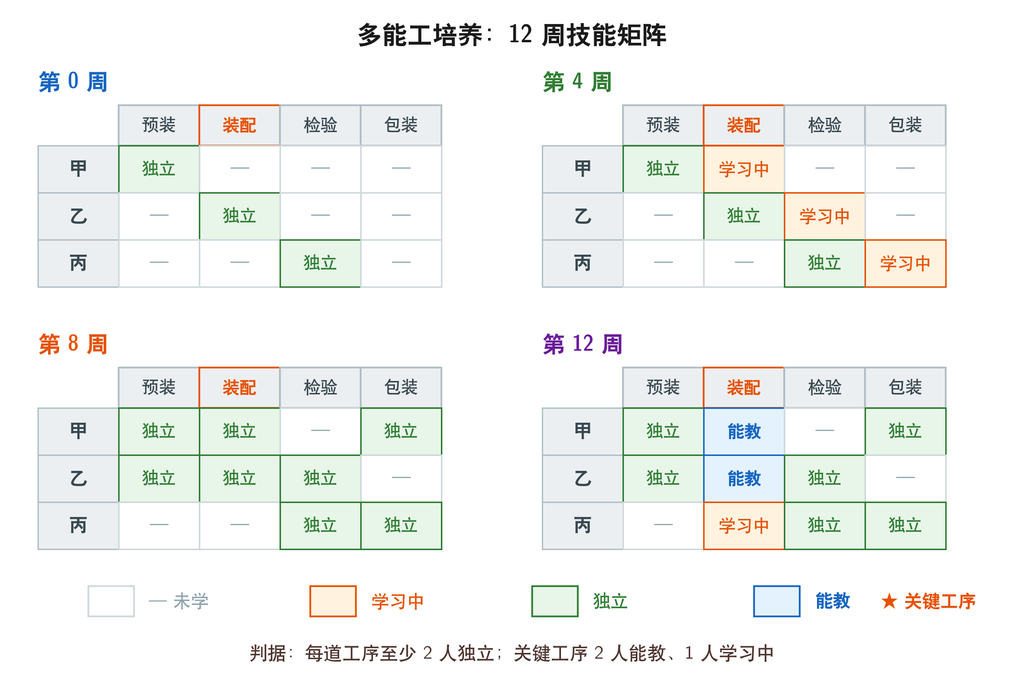

- 多能工：一人掌握多道工序，能顶岗、能协同、能发现前后工序的问题；技能矩阵纵轴员工、横轴工序，格子标“学习中／独立／能教”。
- 轮岗按计划轮换，周期与工序难度匹配，不是“缺人补位”；作用：柔性（支撑少人化）、质量（多视角发现问题）、安全（减少单一姿势累积）。
- 培养四件事缺一不可：标准作业、师带徒、考核、复训；关键工序认证后才上岗，技能等级与薪酬晋升挂钩。
- 判据：关键工序至少两人能独立操作，人员请假不断线；“能教”才算真的会。

## 改善的伦理落点：效率、安全与尊严

- 效率改善的三类代价：劳动强度、安全风险、岗位与尊严
- 安全代价：为提节拍拆护罩、绕过防错、减少点检，都是把风险留给操作者
- 尊严代价：过度监控、节拍压到没有喘息、如厕时间被计时、改善由上面定
- 参与：被改善影响的人要参与设计，而不是被动接受
- 知情：方案、影响、时间表公开，让员工能预期自己的处境
- 分配：效率收益在企业与员工之间怎么分，要有明确说法
- 三条判据：不把风险转给最弱势者；不靠“更累”实现；被影响者有发言权
- 三步框架：利益相关方→伦理问题定位→决策与辩护
- 一句话：改善的正当性，来自被改善者的认可

## 案例：一个工位的效率与安全双改善

- **背景**：装配工位一人一岗，节拍 45.0 s、班产 600 件；料盒在身后，转身取料 2.5 s/件；台面 750 mm，每班弯腰 600 次
- **改善**：料架前置并斜置 30°、台面升至 850 mm、2 kg 手持工具加平衡吊
- **效果**：节拍 42.8 s，班产工时 7.50 h 降到 7.13 h，每班少 22 min，弯腰归零

| 项目 | 改善前 | 改善后 | 变化 |
| --- | --- | --- | --- |
| 节拍 | 45.0 s | 42.8 s | −2.2 s |
| 转身取料 | 2.5 s/件 | 0.8 s/件 | −1.7 s |
| 工具取放 | 1.0 s/件 | 0.5 s/件 | −0.5 s |
| 弯腰 | 600 次/班 | 0 次/班 | −600 次 |
| 班产工时 | 7.50 h | 7.13 h | −0.37 h |

- **同步收益**：工具跌落与腰背负荷下降；颜色加定位防错，取错料减少
- **标准化**：改作业指导书、培训、点检，把改善固定下来
- **判据**：效率与安全同向才叫双改善，只快不安全的改善是负债

## 班组建设与持续改进文化

- 班组是改善的最小单元：人、机、料、法、环都集中在这里
- 班组长三重角色：生产组织、异常处理、育人
- 日常机制：班前会（目标、异常、分工）、班后会（复盘）、周改善会
- 小集团活动：QC 小组、提案、改善发表会，让改善有场合发生
- 绩效可视：安全、质量、成本、交付（SQCD）看板每日更新
- 文化第一条：暴露问题不被责备，否则问题会转入地下
- 文化第二条：改善有功、标准可被挑战，标准不是上级的领地
- 领导行为：走线（Gemba walk）、当场拍板、给资源
- 判据：员工能否说出本班组本月的一项改善和自己的一件提案

## 本部分小结：效率与人的平衡

- 一条主线：现场事实→标准→改善→再标准，循环不止
- 五个判断：三现取证、标准先行、目视透明、人机匹配、伦理有底线
- 效率有两个来源：消除浪费（不伤人）与提高强度（有代价）
- 三个概念顺序不能倒：先省力，再省人，最后少人化
- 人的三重角色：执行者、改善者、受益者，缺一个都不持久
- 伦理底线：不把风险与代价转给最弱势的人
- 下一步：实验课时把“省人”写成线性规划，用模型算清代价
- 一句话：好的改善，让人更轻松地创造更多价值

## 推导留给 AI：现场改善与人的关系

- 防错装置被一线员工故意短接，可能的原因有哪些？如何从设计与管理两方面解决？
- SMED 把内部作业转为外部作业，哪些转换会带来新的安全风险？
- 一个“减人增效”方案，如何用三步框架做伦理分析？
- 查证：工作扩大化与工作丰富化的区别，各举一个制造现场例子。

# 第五部分 · 例题、讨论与 AI 提问

- 真题与逐卷账：ECRS、ESCRI、八大浪费、鱼骨图
- 计算例题快评：标准工时与线平衡（OEE/SMED/看板转课后练习）
- 错题本与讨论：自动化替代的边界、5S 是不是形式主义
- AI 提问：本讲 5 个延伸问题

## 历年真题分布与原题汇编

| 卷次 | 相关题（题号） | 本讲分值 |
| --- | --- | --- |
| 2020 A | 单选 5；简答 2、7；论述五 | 23 分 |
| 2020 B | 单选 4；简答 2、4；论述五 | 23 分 |
| 2021 A | 单选 3、5；简答 2；论述五 | 21 分 |
| 2021 B | 单选 4；简答 2、3；论述五 | 23 分 |
| 2022 A | 简答 5；论述五 | 15 分 |
| 2022 B | 单选 4；简答 2、3；论述五 | 23 分 |

- 四类考点：ECRS 单选 3 分、ESCRI 简答 5 分、八大浪费简答 5 分、鱼骨图论述 10 分；六卷全考 ESCRI 与鱼骨图两项，保底 15 分。
- 单选（多卷）：工业工程改善四大原则是 ECRS（取消、合并、重排、简化），答案 B；干扰项为 PDCA、5W1H、SWOT。
- 简答（各卷）：列举 ESCRI 五原则并简要介绍；列举八大浪费中的五个并简要介绍。
- 论述（各卷）：灯泡坏、水龙头漏、暖气不热、借书机不工作四选一，按人机料法环画鱼骨图并分析主因。
- 六卷里本讲没有计算题：工时与平衡率只在作业和实验里验收。

## 简答给分点：ESCRI 与八大浪费

**ESCRI（六卷简答，5 分）**：列举提高效率的 ESCRI 原则并简要介绍——写五行，每行“字母＋中文＋一句解释或现场例”。

| 原则 | 一句话解释 | 现场一问 |
| --- | --- | --- |
| E 取消 | 去掉不必要的工序、检验与搬运 | 这一步不做行不行？ |
| S 简化 | 降低复杂度，少用力、少用眼 | 能不能更好做？ |
| C 合并 | 把工序、工装、表单并起来 | 能不能并到一起？ |
| R 重排 | 调整顺序与布局，缩短搬运路线 | 换个顺序会不会更顺？ |
| I 新增 | 必要时加工装、防错、自动化 | 要不要加个装置？ |

- 给分：5 条 ×1 分＝名称 0.5＋解释 0.5；只写五个字母最多 2.5 分；易错：把 I 说成“提高效率”（I 是 Increase，指新增）、漏 I、E 与 S 解释互换。
- 八大浪费（多卷简答，5 分）：列举八类中的五个并简要介绍——八类＝TPS 七类＋管理浪费，答题按题干口径写“七”或“八”；给分 5 个 ×1 分＝名称 0.5＋内容 0.5。
- 八大浪费易错：把“停机”当类型（应为等待）、把库存写成“仓库”；管理浪费是根，但最难量化。

## 真题：鱼骨图论述（人机料法环画法与主因）

- **题干**（六卷论述，10 分）：灯泡坏、水龙头漏、暖气不热、借书机不工作，任选其一按人机料法环画鱼骨图并分析主因
- **画法**：鱼头写现象＋时间＋地点；五支各列 2—3 条，再用数据或 5Why 选主因，最后给对策

| 支干 | 可能原因（以灯不亮为例） | 验证方法 |
| --- | --- | --- |
| 人 | 清洁碰松灯头、忘报修 | 查保洁记录、问当事人 |
| 机 | 灯泡烧坏、开关或镇流器故障 | 换灯泡试亮、万用表测通断 |
| 料 | 灯泡规格不符、灯座老化 | 核对规格型号、看灯座 |
| 法 | 无点检报修规程、换灯步骤缺失 | 查制度、查报修工单 |
| 环 | 电压波动、雷雨、粉尘潮湿 | 测电压、查天气与现场 |

- **给分（10 分）**：鱼头 1＋五支齐全 2＋每支≥2 条 3
- **主因与对策**：主因有证据 2＋对策 1＋图面 1
- **主因写法**：根本原因 → 验证方式 → 对策与责任人；“灯不亮”当原因最易丢分

## 真题错题本：本讲五个高频失分点

| 失分点 | 错例 | 正解 |
| --- | --- | --- |
| ESCRI 的 I | 写成“提高效率” | I 是 Increase（新增）；提高效率是这套原则的目的，不是字母含义 |
| 七/八大浪费口径 | 题干问八大，答了七类 | 先看题干：八大浪费＝TPS 七类＋管理浪费（本讲按课本口径） |
| 鱼骨图把现象当原因 | 主因写“灯不亮” | 主因要能验证：灯泡烧坏、镇流器故障，各配验证方法 |
| 节拍与瓶颈混用 | 把瓶颈 50 s 当节拍 | 节拍由需求定、瓶颈由产线定；$CT\le T_{\mathrm{takt}}$ 才达产 |
| 宽放乘错基数 | 标准时间＝观测×(1+A) | 先乘评比得正常时间，再乘 (1+A) |

- 时间分配：单选 2 分钟、简答每题 5 分钟、鱼骨图论述 12–15 分钟
- 答题模板：定义一句＋判据一句＋一个现场例；计算题写公式、代值、单位

## 计算例题快评：标准工时与线平衡

公式

$$T_n=T_o\times R,\quad T_s=T_n\times(1+A);\qquad E=\frac{\sum T_i}{N\,T_{\max}},\quad SI=\sqrt{\frac{\sum (T_{\max}-T_i)^2}{N}}$$

- **题一（标准工时）**：观测均值 5.00 min、评比 1.20、宽放 25%（私事 5＋疲劳 10＋作业 5＋管理 5）→ 正常 6.00 min、标准 7.50 min、8.00 件/h、班产 64 件；班需求 700 件 → 定员 11 人。
- **题一易错**：漏乘评比得 6.25 min（产量高估 20%）；宽放算在标准时间上得 8.00 min（高估 6.7%）。
- **题二（线平衡）**：5 工位 42、48、50、45、40 s（总 225 s）；班可用 420 min、需求 520 件 → 节拍 48.5 s、最少工位 5 个、平衡率 90.0%、$SI=6.21$ s。
- **题二判读**：瓶颈 50 s＞节拍 48.5 s，产能 504 件达不到 520 件；拆 2 s 给 40 s 工位后，平衡率 93.8%、$SI=4.02$ s、产能 525 件。
- **结论**：工位数已最少，加人不如重排；平衡率看平均负荷，$SI$ 看离散程度。

## 课堂讨论：5S 形式主义与自动化省人

- **场景一（5S）**：车间每天下班前 10 分钟做 5S、检查打分、月底评比——如果只打分、不与问题解决挂钩，会发生什么？5S 与安全、质量、效率的关系如何量化？
- **场景二（自动化）**：某电机装配线 8 人/班，上 4 台协作机器人＋视觉检测后 3 人/班、班产 640 件不变——省下的 5 人往哪里去？
- 分企业、员工、政府与工会三组，每组各出 3 条主张与 1 条可执行方案（两题任选其一）。

| 出路 | 适用条件 | 代价与风险 |
| --- | --- | --- |
| 转岗 | 有新岗位且可迁移 | 过渡期效率下降 |
| 再培训 | 企业有培训体系 | 培训费与脱产损失 |
| 自然减员 | 有退休或流失不补 | 技能断层，青黄不接 |
| 裁员 | 无岗位、订单下滑 | 补偿金、士气、雇主品牌 |

- **判据**：效率方案必须同时是“人的方案”，看转岗率、培训时长与单位人工成本；5S 的判据是“是否让问题更容易被发现”。

## AI 提问：本讲 5 个延伸问题

- 让 AI 统计 2020—2022 六卷中本讲考点：各几道、合计几分？逐条给出卷次与题号，再回原卷核对。
- 让 AI 解释 ESCRI 的 I 是“新增”还是“提高效率”，各举一个现场例子，并判断哪种译法更贴合题意。
- 让 AI 论证“管理浪费是最大的浪费”并找出三个反例；再给“自动化省人”的“人的方案”模板，由谁判定成立？
- 让 AI 为“宿舍暖气不热”画人机料法环鱼骨图，每条原因附验证方法；再说明 5S 的投入产出如何向财务说明，以及只能给一条改善建议时选 5S 还是 SMED。
- 用一组 5 工位工时考 AI：标准时间、平衡率、平滑指数，需求 800 件/天时的节拍、工位与瓶颈转移；再列 SMED 换型 45 min 内外部清单，并串起 IE／程序分析／精益／现场改善。

> 提问三件套：给定数据、要求复算、追问反例（数字能复算、出处能翻到原卷）；AI 最容易在年份、题号、分值上编造。

# 第六部分 · 本讲小结、作业与下讲预告

- 三句话小结
- 关键概念清单（20 个术语）
- 作业：概念、计算与分析（100 分）
- 下讲预告：安全与环保的底线；课后阅读与预习

## 本讲小结：方法、精益与人

1. **方法研究把工作变成可测量、可比较的标准**：程序分析看流程、操作分析看人机配合、动作分析看动素；作业测定把时间定成标准工时——没有标准，改善无从比较。
2. **精益把一个个标准连成流**：从价值出发，沿价值流找出八大浪费，用 5S、看板、拉动、SMED 让物料与信息连续流动；库存降下来，问题才会露出来。
3. **人的关系决定改善的边界**：收益归谁、代价由谁承担，岗位、劳动强度与参与权都要写进方案；“减人不减事”必须同时是“人的方案”。

> 先有标准，才有一致的改善；先看见流，才知道改哪里；先问人，才知道改到哪为止。
- 主线回收：标准 → 流 → 人，三步分别对应工作研究、精益生产与伦理落点。
- 复习提示：三句话对应工作研究、精益生产与现场改善，回看按目录对照。
- 自测：合上讲义，用 90 秒复述三句话，每句补一个本讲的数字或现场画面。

## 本讲知识地图：方法—分析—理念—现场—模型

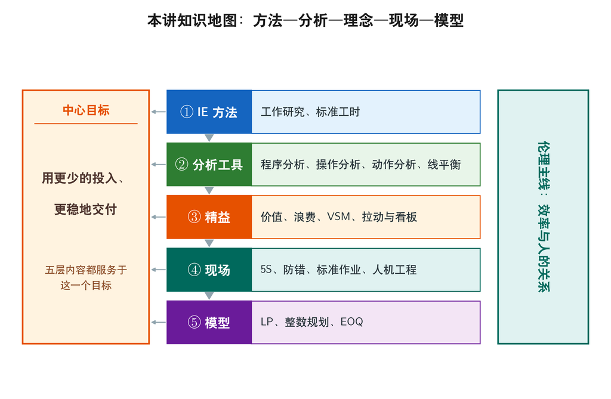

- **方法层**：工作研究（方法研究＋作业测定）→ 标准工时，回答“效率怎么量”
- **分析层**：程序、操作、动作三层＋线平衡与山积表，回答“慢在哪里”
- **理念层**：价值、八大浪费、VSM、连续流、拉动与看板，回答“哪些活动不该做”
- **现场层**：5S、防错、标准作业、人机工程与多能工，回答“改善怎么固化、人怎么办”
- **模型层（实验 2 课时，另排）**：LP、整数规划与 EOQ，回答“资源怎么分最优”
- 三个必会数：标准时间、节拍、平衡率；一条伦理主线：效率与人的关系

## 关键概念清单：20 个术语

| 工作研究 | 分析改善 | 精益 | 现场与量化 |
| --- | --- | --- | --- |
| 方法研究 | 程序分析 | 增值 | TAKT |
| 作业测定 | 操作分析 | 八大浪费 | 平衡率 |
| 标准工时 | 动作分析 | 5S | 防错 |
| 评比系数 | ECRS | VSM | OEE |
| 宽放率 | 5W1H | 看板 | EOQ |

- 四组关系：工作研究定标准，分析改善改流程，精益消浪费，现场与量化把标准跑起来、把账算清楚。
- 会算：标准时间、节拍、平衡率、OEE、EOQ；会判：增值与否、浪费类型、瓶颈位置、改善优先级。
- 抽查：下次课随机抽 5 个术语，各配一句定义与一个现场例子；答不出者回对应页重看。

## 缩写速查：本讲用到的英文缩写

| 缩写 | 英文全称 | 中文 |
| --- | --- | --- |
| IE | Industrial Engineering | 工业工程 |
| MODAPTS | Modular Arrangement of Predetermined Time Standards | 模特法（预定时间标准），简称 MOD |
| MTM | Methods-Time Measurement | 方法时间衡量 |
| PTS | Predetermined Time Standards | 预定时间标准 |
| SIMO | Simultaneous Motion Cycle chart | 双手同时动作图，简称 SIMO chart |
| TPS | Toyota Production System | 丰田生产方式 |
| JIT | Just In Time | 准时制 |
| VSM | Value Stream Mapping | 价值流图 |
| SMED | Single Minute Exchange of Die | 快速换模 |

| 缩写 | 英文全称 | 中文 |
| --- | --- | --- |
| ECRS | Eliminate, Combine, Rearrange, Simplify | 取消、合并、重排、简化 |
| ESCRI | Eliminate, Simplify, Combine, Rearrange, Increase | 取消、简化、合并、重排、新增（提高效率原则） |
| 5W1H | What, Why, Where, When, Who, How | 六问法 |
| 5S | Seiri, Seiton, Seiso, Seiketsu, Shitsuke | 整理、整顿、清扫、清洁、素养 |
| OEE | Overall Equipment Effectiveness | 设备综合效率 |
| EOQ | Economic Order Quantity | 经济订货批量 |
| TAKT | Takt Time（德语 Takt，节拍） | 节拍时间 |
| LP | Linear Programming | 线性规划 |

- 只记“英文全称—中文—用在哪”三件事，不背拼写。
- ECRS 与 ESCRI 的差别在最后一个 I：Increase（新增自动化或工装），不是“提高效率”的缩写。
- TAKT 来自德语，不是英文缩写；Poka-Yoke 也不是缩写，是日文“防错”（中文也译“防呆”）。

## 作业：概念、计算与分析（100 分）

**1. 概念题（20 分）** 五组概念辨析，各配一个现场例子（各 4 分）：方法研究／作业测定、正常时间／标准时间、节拍／瓶颈时间、推动／拉动、错误／缺陷。

**2. 计算题（50 分）**

- 机加工序观测 4 个周期 5.20、5.40、5.60、5.80 min，评比 1.10，宽放 15%：求正常时间、标准时间与小时产量（12 分）。
- **装配线**：960 min、停机 120 min，需求 600 件/天。
- 该线 5 工位为 70、78、86、74、82 s：求节拍、最少工位数、平衡率与日产能（24 分）；瓶颈降至 82 s 后如何（14 分）。

**3. 分析题（30 分）** 5S 得分 95 分，但换型 45 min、在制品堆到通道、停机频繁：① 列 4 类浪费并给出证据（12 分）；② ECRS 提 2 条改善并配指标（12 分）；③ 对岗位与劳动强度的影响（6 分）。

- 要求：先算节拍再判断产能；公式、代值、单位齐全；下次课前交。课后练习（不计分）：OEE 三率、SMED 换型占比与经济批量、看板数三题。

## 下讲预告与课后清单

- 本讲谈“把事做快做省”，下一讲问：效率能以伤人或污染为代价吗？
- **安全工程**：海因里希法则 1 : 29 : 300；能量意外释放理论；危险源分两类。
- **事故树 FTA**：顶上事件与基本事件、与门／或门，布尔化简后求最小割集与最小径集。
- **责任与环保**：安全事故 vs 安全责任事故；三废治理、清洁生产与双碳；法规硬约束。
- **复习与预习**：教材 3.2 节复习、3.3 节预习；阅读《精益思想》《改变世界的机器》《丰田生产方式》。
- **提交**：1 页阅读笔记（3 个问题＋1 个疑问）＋1 个身边的浪费或安全隐患观察。
- **预习问题**：① 1 : 29 : 300 的适用边界？② 与门、或门对应怎样的割集？③ 三废成本由谁承担？

# 第七部分 · 实验课时（另排）：线性规划与 IE 例子

- 实验目标、环境与四步闭环：建模 → 求解 → 解释 → 应用
- 线性规划：三要素与假设、图解法、单纯形思想、影子价格与灵敏度
- 三个 IE 例子：线平衡整数规划、人机联合班次、EOQ
- 实验报告六必答项与评分、现场验收
- **承上**：前四部分讲的是判断与算法；本部分（实验 2 课时，另排）要回答怎样把 IE 问题写成线性规划、求解并解释结果。

## 实验目标、环境与四步闭环

- **目标**：把一段生产问题抽象成“变量—目标—约束”，用代码求解并解释结果——不是“跑一遍代码”。
- **四步闭环**：建模 → 求解 → 解释 → 应用，每一步都要留下可检查的产物。
- **建模**：先画关系图，再定决策变量、目标函数、约束条件；**求解**：二维用图解法，多维用单纯形或求解器，手算至少完整做一遍。
- **解释**：读最优解、紧约束、影子价格与灵敏度，回答“哪个资源最值钱”；**应用**：把解翻译成排产、采购、加班、外协的具体动作。
- **环境**：Python 3.10＋；PuLP（默认）或 `scipy.optimize.linprog`；Jupyter Notebook 或 .py 脚本。
- **安排**：第 1 课时（45 分钟）建模与图解法；第 2 课时（45 分钟）PuLP、三个 IE 例子与报告验收。
- **提交**：实验报告（问题—模型—代码—结果—解释，正文 ≤6 页）与现场抽问。
- **先修**：一元一次不等式、直线方程；EOQ 只用到一次求导。

## 线性规划的三要素与四个假设

- **决策变量** $x_j$：模型要回答“做多少、买多少、分给谁”。
- **目标函数**：$\max z=\sum_j c_jx_j$ 或 $\min$，系数是每单位贡献（或成本）。
- **约束条件**：资源、需求、工艺、政策，统一写成 $\sum_j a_{ij}x_j\le b_i$ 等形式。
- **四个假设**：比例性、可加性、可分性、确定性；前两条合起来就是线性。
- **比例性**：单位消耗与单位贡献固定、不随批量变化（没有规模经济）；**可加性**：各活动的资源消耗与利润可以直接相加。
- **可分性**：变量可取小数，只能整件时换整数规划；**确定性**：参数已知，波动大时做灵敏度分析或随机规划。
- **建模四问**：决定什么？追求什么？受什么限制？数据从哪里来？

## 案例一：两种产品的日产量决策

**某车间生产 P1、P2 两种产品，共用机时与工时两类资源。**

| 产品 | 机时（h/件） | 工时（h/件） | 单件利润（元） |
| --- | --- | --- | --- |
| P1 | 2 | 1 | 40 |
| P2 | 1 | 2 | 30 |
| 可用 | 100 | 80 | — |

$$\begin{aligned}\max\ &z=40x_1+30x_2\\ \mathrm{s.t.}\ &2x_1+x_2\le100,\quad x_1+2x_2\le80,\quad x_1,x_2\ge0\end{aligned}$$

- 最优 $x_1=40$ 件/日、$x_2=20$ 件/日，$z=2200$ 元/日；机时 100 h、工时 80 h 全部用尽
- 只产一种：$x_1=50$ 得 2000 元、$x_2=40$ 得 1200 元；混合更优，因两类资源的消耗结构互补
- 若 P1 最多 30 件，加 $x_1\le30$ 后最优为 $(30,25)$、$z=1950$ 元；系数同乘 0.9 仍产 $(40,20)$

## 图解法：可行域、顶点与最优

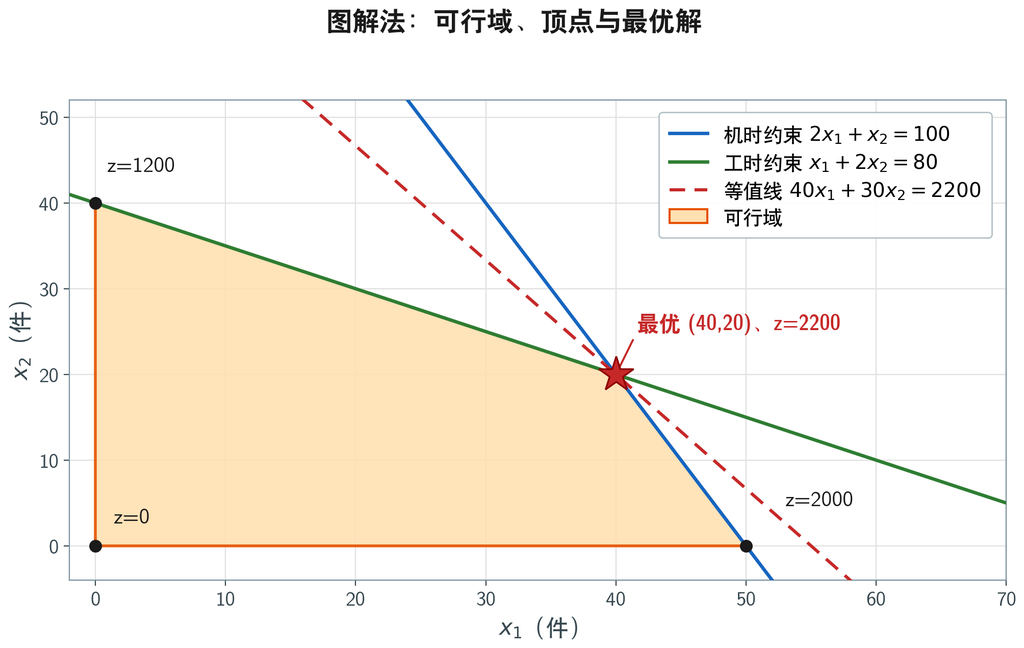

可行域、顶点与最优解：max z=40x₁+30x₂，最优 (40,20)、z=2200

- 三个动作：画线（每条约束取满足不等号的一侧）、定侧（半平面交集＝可行域，凸多边形）、平移（等值线沿梯度方向平移）。
- 最优解必在顶点或整条边上取得；本算例四个顶点 $(0,0)$、$(50,0)$、$(40,20)$、$(0,40)$ 对应 $z=0$、$2000$、$2200$、$1200$，最优 $(40,20)$。
- 最优处两条约束同时取等号，称为**紧约束**；若 $c_1$ 变到 70，等值线变陡，最优点跳到 $(50,0)$，$z=3500$。
- 四种结局：唯一最优、多重最优、无界、无可行解；图解法只适合二维，但“顶点＋等值线”的直觉一直有用。

## 单纯形法：沿可行域的边走

- 图解法靠眼睛，单纯形靠表格；两者走的是同一条路：顶点到相邻顶点
- 化标准形，用松弛变量（≤ 约束补的非负变量）构造初始基可行解 $(x_1,x_2,s_1,s_2)=(0,0,100,80)$
- 检验数 $\sigma_j=c_j-z_j>0$ 的变量进基，最小比值法则确定离基变量
- 主元消去后得到新顶点；重复到全部检验数非正为止

| 轮次 | 进基 | 离基 | 顶点 | $z$（元/日） |
| --- | --- | --- | --- | --- |
| 0 | — | — | $(0,0)$ | 0 |
| 1 | $x_1$ | $s_1$ | $(50,0)$ | 2000 |
| 2 | $x_2$ | $s_2$ | $(40,20)$ | 2200 |

- 第二轮后检验数 $(-50/3,-20/3)$ 全部非正，停止，当前顶点最优
- 最终表：$x_1=40-\frac{2}{3}s_1+\frac{1}{3}s_2$、$x_2=20+\frac{1}{3}s_1-\frac{2}{3}s_2$
- 目标行 $z=2200-\frac{50}{3}s_1-\frac{20}{3}s_2$，松弛变量系数正是下一节影子价格的相反数

## 对偶与影子价格：资源怎么定价

- 对偶问题：不生产产品，而是给资源定价；原问题最大化产品利润、对偶最小化资源总价值，原约束↔︎对偶变量、原变量↔︎对偶约束。
- **强对偶**：原问题与对偶问题最优值相等（本例都是 2200 元/日）；**互补松弛**：$x_j>0$ 时对偶约束取等号，松弛变量 $s_i>0$ 时 $y_i=0$。
- 影子价格 $y_i$：第 $i$ 种资源增加 1 单位时最优目标值的增量，不是会计成本，而是边际价值。

| 项目 | 影子价格 | 用量／可用 | 决策含义 |
| --- | --- | --- | --- |
| 机时 | 16.67 元/h | 100／100 h | 外协报价低于 16.67 元/h 才划算 |
| 工时 | 6.67 元/h | 80／80 h | 加班工资低于 6.67 元/h 才划算 |
| P1 上限 60 件 | 0 | 40／60 件 | 约束未用满，放松它不增值 |

- 三个用法：稀缺度排序（先扩机时）、外包与加班决策、内部转移定价；机时影子价格是工时的 2.5 倍。
- 有效区间：机时 $[40,160]$、工时 $[50,200]$；超出区间基变、影子价格要重新求，不能拿 16.67 无限外推。

## 用 PuLP 求解：十行代码与三个检查

```python
import pulp
m = pulp.LpProblem("mix", pulp.LpMaximize)
x1 = pulp.LpVariable("x1", lowBound=0); x2 = pulp.LpVariable("x2", lowBound=0)
m += 40*x1 + 30*x2
m += 2*x1 + x2 <= 100, "machine"
m += x1 + 2*x2 <= 80, "labor"
m.solve(pulp.PULP_CBC_CMD(msg=False))
print(x1.value(), x2.value(), pulp.value(m.objective))
print(m.constraints["machine"].pi, m.constraints["labor"].pi)
```

- 输出：`40.0 20.0 2200.0`；`pi` 就是影子价格（约 16.67 与 6.67），所以约束必须起名
- **三个检查**：状态是否为 `Optimal`；把解代回每条约束看余量；与图解法顶点对照

## PuLP 调错：四类常见报错与改法

- 症状一：`NameError: name 'pulp' is not defined`——忘记 `import pulp`
- 症状二：`TypeError: unsupported operand`——约束没写成 `<=` 表达式，或把 `=` 当成赋值
- 症状三：`m.status` 不是 `Optimal`——漏非负、方向写反、资源上限抄错
- 症状四：`KeyError: 'machine'`——取影子价格时约束没起名，或求解未成功

```python
print(m.status)                                           # 1 = Optimal
print({v.name: v.value() for v in m.variables()})         # 变量取值
for n, c in m.constraints.items(): print(n, c.pi, c.slack)  # 影子价格与松弛
```

- 排查顺序：先看 status，再打印模型 `print(m)` 对照数据，最后读解
- 三个检查：状态是否最优、解代回每条约束看余量、与图解法顶点对照
- 注意：CBC 对退化问题可能给多组对偶解，影子价格要结合单侧边际核对

## 灵敏度分析：参数变了决策还稳吗

- 建模参数都是估计值，灵敏度回答“估错了会不会改变决策”
- 目标系数：$c_1\in[15,60]$、$c_2\in[20,80]$ 时，最优解仍是 $(40,20)$
- 右端项：$b_1\in[40,160]$、$b_2\in[50,200]$ 时，基不变、影子价格不变
- 机时加 10 h，利润增加 $10\times16.67=166.7$ 元；工时加 10 h，增加 66.7 元

| 参数 | 当前值 | 允许范围 | 越界后的最优解 |
| --- | --- | --- | --- |
| $c_1$ | 40 | $[15,60]$ | $c_1>60$ 取 $(50,0)$；$c_1<15$ 取 $(0,40)$ |
| $c_2$ | 30 | $[20,80]$ | $c_2>80$ 取 $(0,40)$；$c_2<20$ 取 $(50,0)$ |
| $b_1$ | 100 | $[40,160]$ | $b_1>160$ 时 $x_2=0$；$b_1<40$ 时 $x_1=0$ |
| $b_2$ | 80 | $[50,200]$ | $b_2>200$ 时 $x_1=0$；$b_2<50$ 时 $x_2=0$ |

- 越界示例：$c_1=70$ 时最优变 $(50,0)$，$z=3500$ 元/日
- 把区间画成图：横轴参数、纵轴最优值，折点就是换基的位置
- 大幅扰动不能外推，要重新求解；报告至少做一个系数、一个右端项

## 从 LP 到 APS：排产中的线性规划

- APS 回答“有限产能下，哪个订单、在哪条线、做多少、什么时候做”；LP 擅长“量的分配”。
- 一般形式：$\max\sum_i m_ix_i$，$\mathrm{s.t.}\ \sum_i a_{ri}x_i\le C_r$，$0\le x_i\le d_i$。
- 案例：A、B、C 单件毛利 50、40、30 元，需求上限 100、120、80 件；两条线可用工时 200、180 h，单件工时 A 2／1、B 1／2、C 1／1 h。
- LP 解：A 46.7、B 26.7、C 80 件，利润 5800 元；取整 47、26、80 件仍可行，利润 5790 元（差 0.17%）。
- 分工：LP 给“量”，MILP 给“开不开、换不换型”，CP 给“先后顺序”，组合才是 APS；MRP 假设无限产能，APS 把产能写成约束。
- 与实验的接口：线平衡整数规划、班次整数规划是同一套“变量—目标—约束”语言。

## 线平衡的整数规划：分配与节拍

| 任务 | 工时（s） | 紧前任务 |
| --- | --- | --- |
| A | 40 | — |
| B | 30 | A |
| C | 50 | A |
| D | 20 | B、C |
| E | 40 | D |

- **目标**：5 个任务分到 3 个工位，最小化节拍 $T$，即各工位负荷的最大值
- **变量**：$x_{ij}\in\{0,1\}$ 表示任务 $i$ 分到工位 $j$
- **约束**：$\sum_j x_{ij}=1$，$\sum_i t_ix_{ij}\le T$，前序任务工位号 ≤ 后续任务
- **最优**：工位 1 为 A、B（70 s）、工位 2 为 C、D（70 s）、工位 3 为 E（40 s），$T^*=70$ s
- **下界** $180/3=60$ s，任务不可拆、先后关系卡住，整数解只能做到 70 s
- 平衡率 $=180/(3\times70)=85.7\%$；规模大时用 MILP 或 OR-Tools

## 人机联合的班次整数规划

- 场景：设备连续运行，按 4 h 一个产能块统计所需看管人数，共 6 块
- 每人上一个 8 h 班，覆盖相邻两个块；$x_i$ 为第 $i$ 块开始时上班的人数
- 需求 $d=(4,6,8,7,5,3)$ 人；约束 $x_i+x_{i-1}\ge d_i$，下标按 6 循环
- 目标 $\min\sum_i x_i$，$x_i$ 取非负整数
- 总需求 33 人·块，每班覆盖 2 块，下界 $\lceil33/2\rceil=17$ 人
- 一组最优解 $(4,2,6,1,4,0)$，共 17 人，恰好达到下界
- 第 6 块实际 4 人、需求 3 人，多出的 1 人是 8 h 班跨两个块带来的整班余量
- 分工扩展：加技能矩阵 $x_{ij}\le a_{ij}$ 与“每人每班最多一岗”，变成人机分配模型
- 整数解要用分支定界；本例松弛恰好为整数，不能当作通例

## EOQ 与多期库存的 LP 视角

- EOQ 回答“一次订多少”：$TC(Q)=DS/Q+QH/2$，令导数为 0 得 $Q^*=\sqrt{2DS/H}$
- 算例：$D=10000$ 件/年、$S=200$ 元/次、$H=10$ 元/（件·年），得 $Q^*=632.5$ 件、$TC^*=6324.6$ 元/年
- EOQ 是凸的非线性模型，不是 LP；但库存平衡可以写成线性约束
- 多期批量：$I_t=I_{t-1}+Q_t-d_t$，$0\le Q_t\le C_t$，$\min\sum(Sy_t+hI_t)$
- 固定开单成本用 $Q_t\le My_t$、$y_t\in\{0,1\}$ 表示，模型变成 MILP
- 算例：$d=(100,120,80)$、$S=500$ 元/次、$h=2$ 元/（件·期）、产能 150，最优 $(150,150,0)$，成本 1260 元，每期开单则为 1500 元
- 精益含义：降低 $S$ 与 $H$ 都会让最优批量变小、库存变低

## 实验报告：六必答项与评分

- **提交物**：PDF 报告（正文 ≤6 页）＋代码＋运行输出，命名“学号-姓名-实验3”；下次课（第 4 讲）前提交，现场抽 1 个算例口述。
- **必答六项**：三要素与单位、紧约束、影子价格、两个灵敏度、决策含义、局限。
- **AI 使用**：可辅助查错与改写，须注明提示词与人工核对；数据与代码可追溯，禁止抄袭与编造运行结果。

| 评分项 | 分值 | 要求 |
| --- | --- | --- |
| 问题与模型 | 35 | 变量、目标、约束齐全；假设写明依据，量纲一致 |
| 求解与代码 | 20 | 代码可运行；结果与图解法或手算一致 |
| 结果与灵敏度 | 25 | 解释最优解与资源余量；至少做一个参数扰动 |
| 规范与诚信 | 10 | 结构完整；AI 使用声明；数据与代码可追溯 |
| 答辩验收 | 10 | 现场口述建模思路，答出变量与约束的含义 |
| 合计 | 100 | 报告不超过 6 页（不含代码） |

- 内容：1 个线性规划模型（生产组合或自选 IE 场景）＋1 个 IE 例子（生产线平衡、人机联合、EOQ 三选一）。

## 从模型到决策：把最优解讲清楚

- 一条主线：现实问题 → 数学模型 → 算法求解 → 结果解释 → 管理动作
- 三个模型：LP 管连续分配，ILP 管离散选择，NLP 管批量与曲线关系
- 三个数：案例一 2200 元/日、影子价格 16.67 与 6.67 元/h、EOQ 632.5 件
- 三个坑：单位不统一、不等式方向写反、把 LP 松弛解当整数解
- 一句判断：如果解释不了影子价格，就还没有真正解完这道题
- 从模型到决策：先看紧约束，再看影子价格，最后看灵敏度区间
- 实验之外：APS 排产、库存优化、线平衡都是同一套“变量—目标—约束”语言

## 推导留给 AI：实验课时（线性规划与 IE 例子）

- 若把目标改为最小化成本，图解法与单纯形法的结论会怎样变？让 AI 改写模型并验证。
- 影子价格为什么随约束结构变化？构造一个“机时影子价格恰为 30 元/机时”的模型并说明条件。
- 生产线平衡的 LP 松弛下界与整数解差距说明什么？举一个任务不可拆分的例子。
- EOQ 在需求波动与数量折扣下如何修正？让 AI 给出两个修正模型并比较。